# Voronoi To The World

The mixed cases where
$$x_{n_{1}} < x_{n_{2}} < x_{n_{3}}$$
or
$$x_{n_{1}} > x_{n_{2}} > x_{n_{3}}$$
are indeterminate (Figure 18 (c), Figure 18 (d)). Depending upon the vertical positioning of the sites the central arc can collapse or expand as the sweep line progresses. The behavior in these cases can probably be worked out with some clever geometry, but I have yet not been able to figure out that geometry myself. Consequently I will use the more direct approach mentioned above.

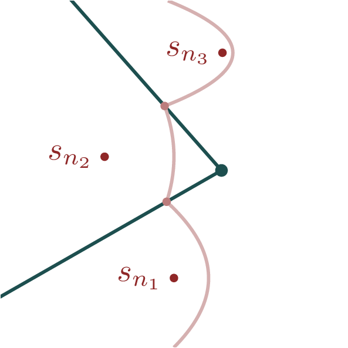

(a)

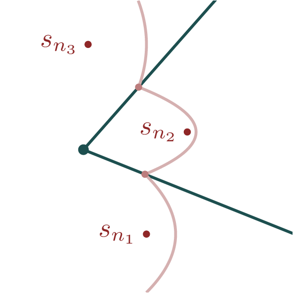

(b)

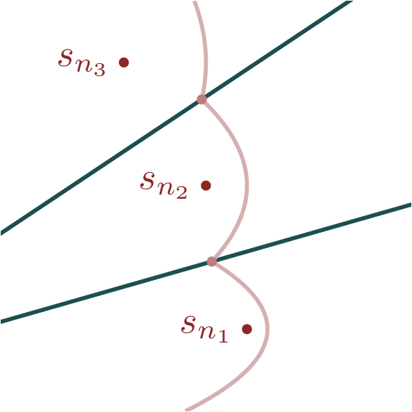

(c)

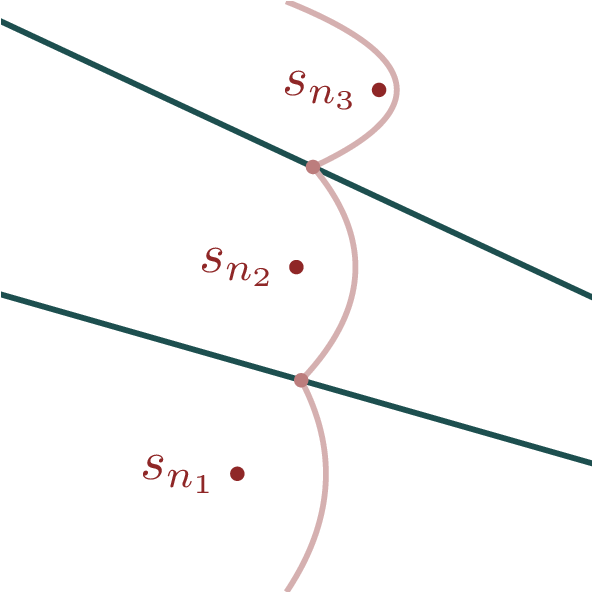

(d)

Figure 18: The central arc of any triplet of neighboring beach line arcs, here generated by the sites $s_{n_{1}}$, $s_{n_{2}}$, and $s_{n_{3}}$, will not always collapse as the sweep line progresses forward. (a) If $s_{n_{2}}$ is behind the other two sites then the arc it generates will eventually collapse, but (b) if $s_{n_{2}}$ is ahead of the other two sites then the arc it generates will only ever expand. (c, d) When $s_{n_{2}}$ is in between the two other sites we need additional information to determine if the corresponding arc will collapse.

If a central arc will eventually collapse as the sweep line progresses then that collapse defines **vertex event**, also known as a **circle event**, at $S = x_{c} + r$. At this sweep line position the breakpoints $b_{ n_{1} n_{2} }$ and $b_{ n_{2} n_{3} }$ will intersect at $(x_{c}, y_{c})$, defining a new vertex that we can add to the Voronoi graph (Figure 19). This vertex then spawns a new Voronoi edge along which the new merged breakpoint $b_{ n_{1} n_{3} }$ will flow.

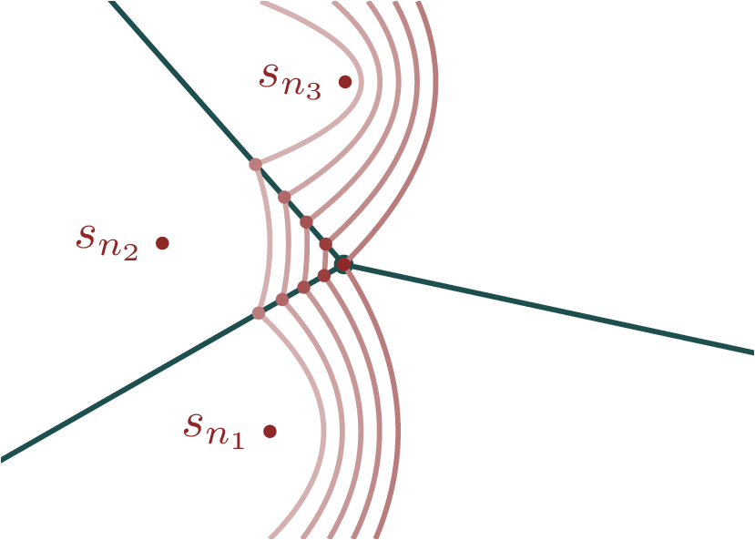

Figure 19: When a central arc collapses, two Voronoi edges terminate at a Voronoi vertex and a new Voronoi edge between the sites that generate the remaining arcs is created.

## 3.5 The Algorithm

Now that we know how and when the topology of a beach line can change we can organize those changes into an algorithm that builds up a Voronoi graph dynamically.

Fortune’s algorithm starts with an **event queue** consisting of events defined by sweep line positions where an arc is added to or removed from the beach line. The algorithm then proceeds iteratively, processing each event in the queue one at a time, expanding the structure of the Voronoi graph, and adding new events as necessary. Initially the event queue is filled with only site events, one for each site, but vertex events are also added as the site events are processed.

In this section we’ll review the basic steps required to process both site and vertex events, as well as clean up after the event queue has been fully processed. Section 4 will focus on the implementation of these steps, which becomes a good bit more complicated if we want to ensure efficient computation.

### 3.5.1 Site Events

Processing a site event requires adding a new arc to the beach line. To do this we have to scan across the current beach line to find the existing arc that meets the height of the new event. We then split that arc in two, inserting a new arc generated by the new site into the beach line along with two new, neighboring breakpoints.

Inserting a new arc into the beach line can also modify the remaining event queue.

For one the new arc will disrupt any triplets of neighboring arcs that contain the split arc. If any of those disrupted arc triplets correspond to future vertex events then they have to be removed from the event queue.

At the same time inserting a new arc also creates two triplets of neighboring arcs, each of which could potentially spawn a vertex event. If the central arc of any of these triplets eventually collapses then we need to add a new vertex event to the event queue where the central arc will be removed.

### 3.5.2 Vertex Events

Our first task when we encounter a vertex event in the event queue is to expand the current Voronoi graph. This starts by adding a new Voronoi vertex, connecting it to two of the previously existing Voronoi edges, and then creating a new Voronoi edge. Exactly how we accomplish this expansions depends on how the graph itself is being implemented.

Once the Voronoi graph has been updated we then remove the central arc from the beach line and update the breakpoints appropriately.

Lastly we have to clean up the event queue. The removal of the central arc will invalidate any vertex event in the event queue where the central arc was previously neighbors with the removed arc. On the other hand the removal also creates two new triplets of neighboring arcs along the beach line, each of which could spawn a new vertex event. If any of these triplets feature a collapsing central arc then we have to add a corresponding vertex event to the event queue.

Again to make this a bit more concrete let’s consider an initial beach line comprised of the five successive arcs,
$$( \alpha_{1}, \alpha_{2}, \alpha_{3}, \alpha_{4}, \alpha_{5}).$$
At a vertex event the central arc $\alpha_{3}$ collapses, resulting in the new beach line
$$( \alpha_{1}, \alpha_{2}, \alpha_{4}, \alpha_{5}).$$
.

This vertex event breaks two initial triples, $( \alpha_{1}, \alpha_{2}, \alpha_{3} )$ and $( \alpha_{3}, \alpha_{4}, \alpha_{5} )$, invalidating any associated vertex events still in the event queue. At the same time the deletion of $\alpha_{3}$ introduces two new triples, $( \alpha_{1}, \alpha_{2}, \alpha_{4} )$ and $( \alpha_{2}, \alpha_{4}, \alpha_{5} )$, each of which could define new vertex events.

### 3.5.3 Clean Up

As we process events the queue will eventually empty. When there are no more events to process the algorithm will have found all of the Voronoi vertices and all of the Voronoi edges. That said some of those edges will be dangling, anchored to a vertex on only one side because they stretch out to infinity in the other direction (Figure 20 (a)).

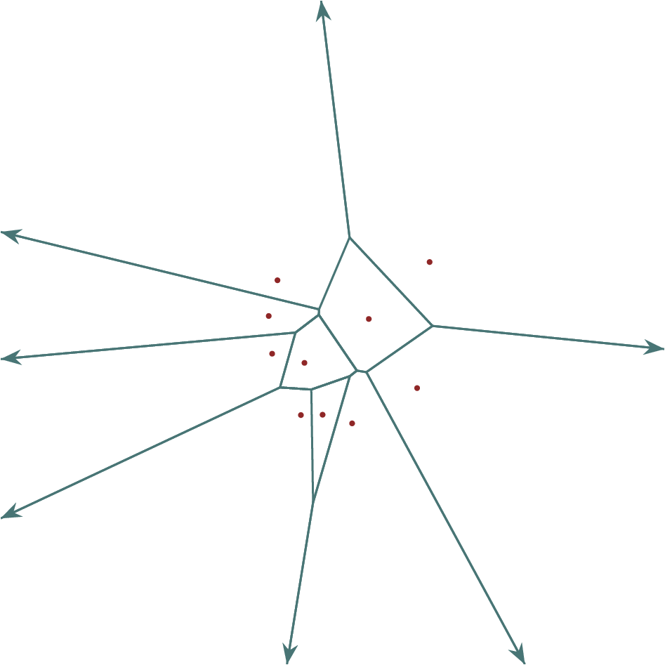

(a)

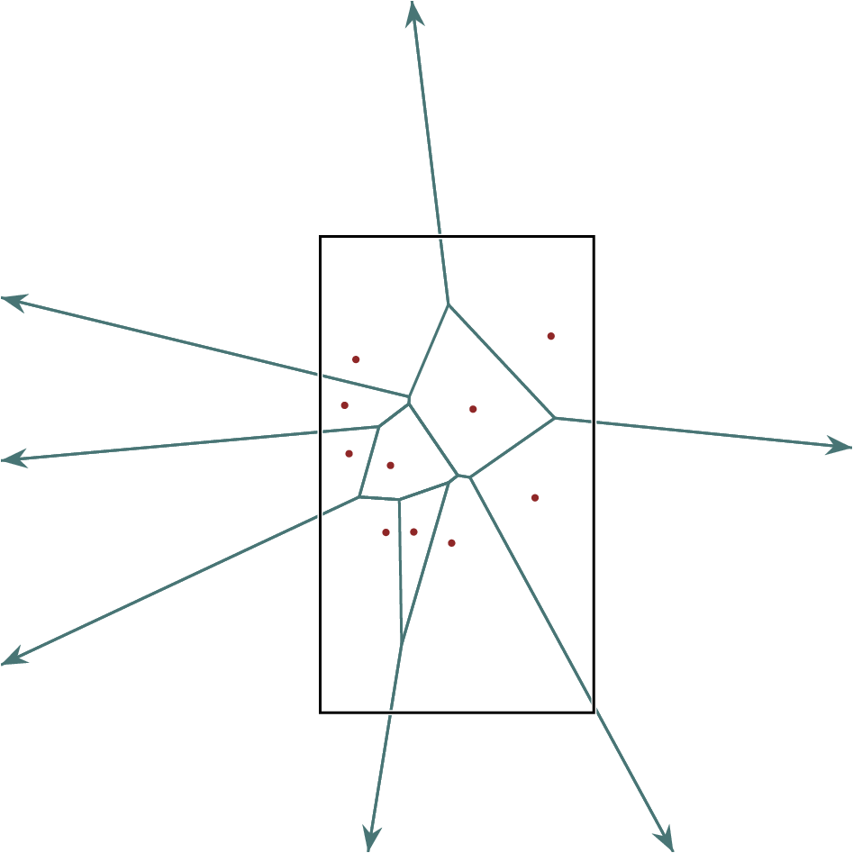

(b)

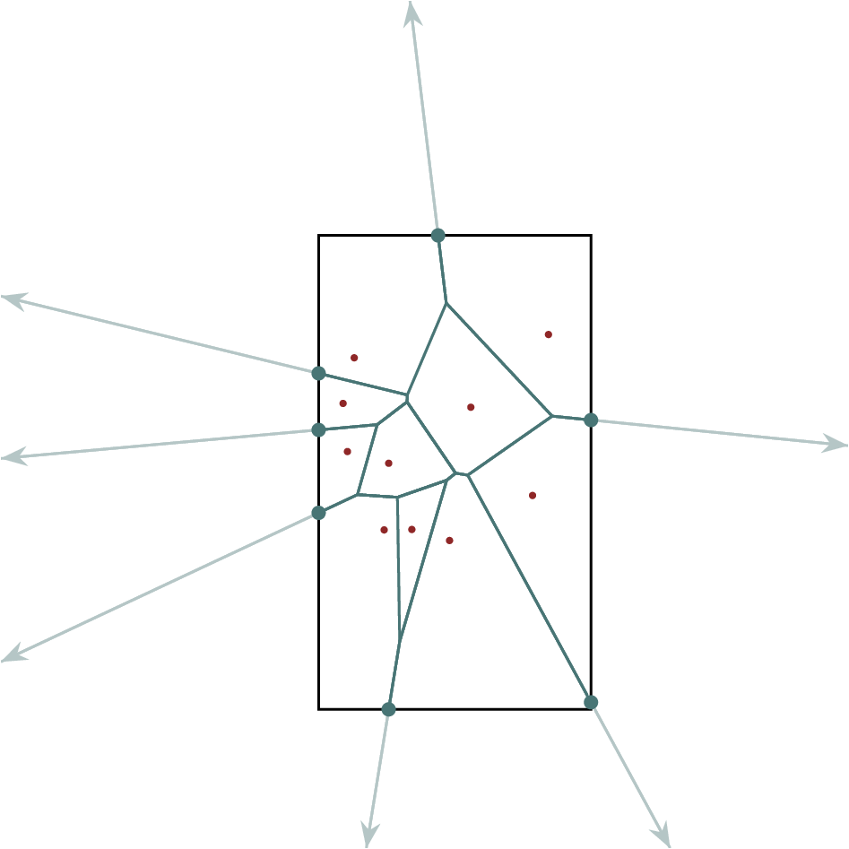

(c)

Figure 20: (a) After running Fortune’s algorithm some of the edges in the Voronoi graph will be connected to vertices on only one side. The other side extends out towards infinity. (b) When visualizing a Voronoi graph in practice we can consider only a finite range of values. The best we can do is visualize the graph within a finite bounding box that contains all of the Voronoi vertices. (c) For visualization purposes we can anchor any dangling edges to points where they meet the bounding box.

We can handle these dangling edges in a few different ways. For example from a graph theory perspective we could anchor any dangling edges to a single “vertex at infinity” that quantifies the common unboundedness of those edges. This approach, however, does not yield particularly compelling visualizations.

For visualization purposes it is more useful to create a rectangular **bounding box** that contains all of the Voronoi vertices (Figure 20 (b)), and then anchor the dangling edges to points along this rectangle (Figure 20 (c)). Specifically the new anchor for a dangling edge will be the point where the perpendicular bisector between the two associated sites intersects with the bounding box.

# 4 Implementing Fortune’s Algorithm

Once we’ve built up enough familiarity with planar geometry, the motivation for Fortune’s algorithm, particularly the utility of a beach line and its evolution, becomes less obscure. That said, there is still work to do to ensure that we can implement the algorithm in a way that achieves its maximum possible performance.

For example when processing a site event we need to be able to efficiently search through the arcs on the current beach line. If we naively scan through the *entire* beach line every time we process a new site event then the the number of operations needed to implement Fortune’s algorithm with scale with not $N \log N$ but rather $N^{2}$. To achieve that $N \log N$ scaling we need to implement the beach line in a way that allows for efficient searching.

Similarly we need to keep track of the next event while we add and delete events from the event queue. We could accomplish this by sorting the entire event queue after every update, but this is wasteful and also spoils the optimal $N \log N$ scaling.

Fortunately (pun very much intended) if we leverage some standard data structures from computer science then we can avoid these potential slowdowns and implement Fortune’s algorithm as efficiently as possible.

## 4.1 Implementing Voronoi Graphs

In theory graphs can be implemented with a just list of points for each vertex and list of pairs of points for each edge. While these lists allow us to draw a graph easily enough, they don’t provide enough information to perform basic graph operations, such as tracing along paths of edges to derive faces.

The **doubly-connected edge list** (Berg et al. 2008) is a data structure that efficiently captures not only the components of a graph but also the relationships between those components. These relationships in turn make it straightforward to efficiently implement graph algorithms.

A doubly-connected edge list is itself built up from lists of three primitive data structures: half-edges, vertices, and faces.

### 4.1.1 Half-Edges

Doubly-connected edge lists don’t actually represent undirected edges. Instead the data structure splits each undirected edge into two directed edges known as **half-edges** (Figure 21).

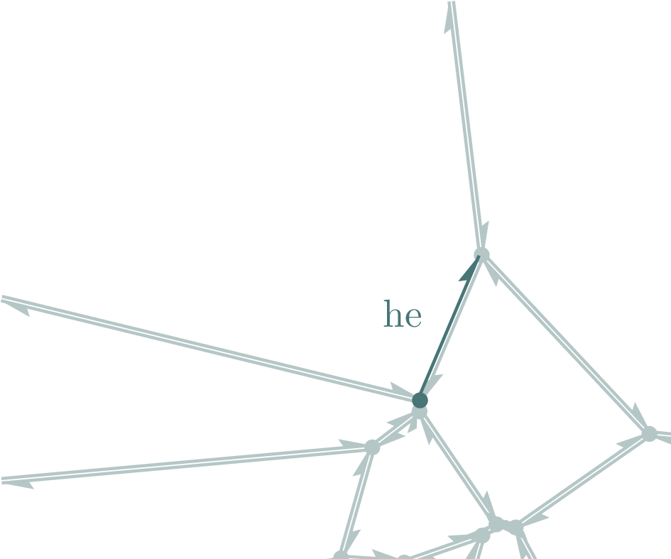

Figure 21: Doubly-connected edge lists represent undirected edges with a pair of directed half-edges. Each half-edge includes references to other structures in the doubly-connected edge lists, including the vertex from which the half-edge originates and neighboring half-edges.

To situate them within the full graph, each half-edge is endowed with a collection of references to other objects in the doubly-connected edge list. For example each half-edge includes a reference to the vertex from which the half-edge originates. Similarly each half-edge includes references to three other half-edges – the *previous* half-edge that points into it, the *next* half-edge that it points into, and the *twin* half-edge that completes it to form a full undirected edge (Figure 22). Finally each half-edge includes a reference to the face located to its left.

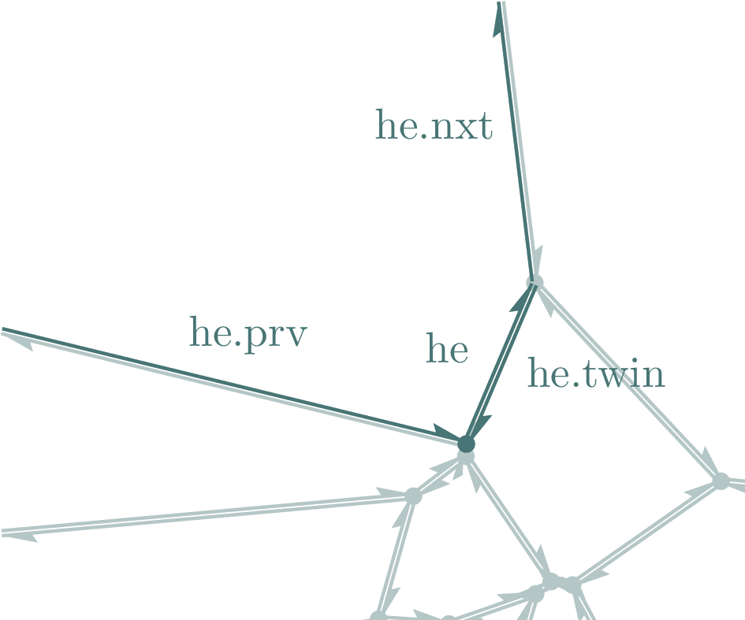

Figure 22: Each half-edge in a doubly-connected edge lists includes reference three other half-edges. The previous half-edge, here labeled “he.prv”, identifies the half-edge that points into it while the next half-edge, here labeled “he.nxt”, identifies the half-edge that it points into. Finally the twin half-edge, here labeled “he.twin”, identifies the half-edge that completes it to form a full undirected edge.

These references make a variety of graph operations straightforward to implement. For instance the originating vertex and twin half-edge references provide enough information to draw a half-edge as a directed line segment, starting at the position of the originating vertex and then ending at the position of the twin’s originating vertex.

Similarly we can use the previous and next references to trace through paths in the graph. These paths can then be used to quantify topological information about the graph, such as the configuration of the faces.

Voronoi graphs generally feature unbounded edges, with only one side terminating at a vertex and the other shooting off towards infinity. In this case some of the half-edges will feature empty next half-edge references while their twins will feature empty originating vertex and previous half-edge references.

### 4.1.2 Vertices

Each vertex in a doubly-connected edge list is specified with its spatial position and a reference to any one half-edge that originates from it (Figure 23). The relationship of a vertex to the rest of graph can then be completely reconstructed from this information.

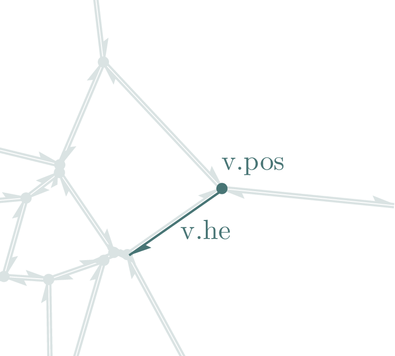

Figure 23: Each vertex in a doubly-connected edge list includes its spatial position, here denoted “v.pos” and a reference to any one half-edge that originates from it, here denoted “v.he”.

For example all of the half-edges that originate at a given vertex can always be accessed by repeatedly following the twin and next references from the one included half-edge (Figure 24). Equivalently we can iteratively follow the previous and then twin references. In the same way we can also access the half-edges that *terminate* at a given vertex.

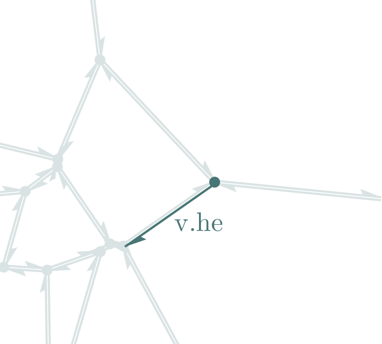

(a)

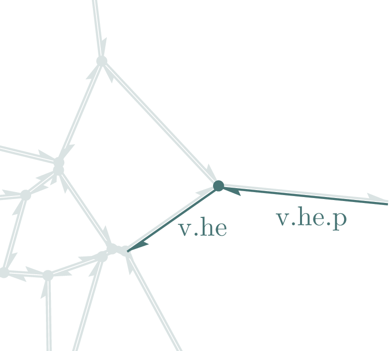

(b)

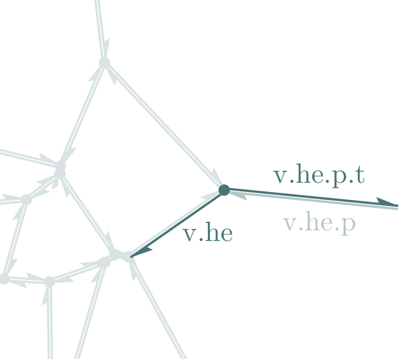

(c)

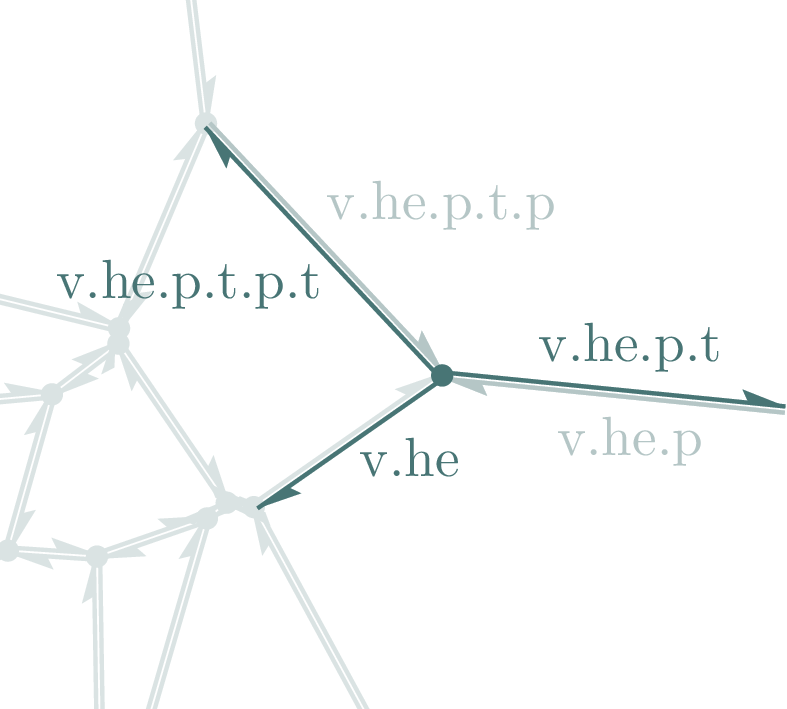

(d)

Figure 24: (a) The one half-edge referenced in a vertex object is enough to reconstruct the entire structure of the graph around that vertex. For example if we follow the reference to (b) the previous half-edge, “v.he.p”, (c) and then its twin, “v.he.p.t”, we recover another half-edge that originates from that vertex. (d) Repeating this operation recovers all of the half-edges that originate from that vertex.

Once we can access all of the neighboring half-edges we can then access additional information about the local structure of the graph. Neighboring vertices, for instance, are given by the originating vertex references of the twin of any half-edge that originates at the initial vertex.

### 4.1.3 Faces

Finally each face in the graph is specified by any one half-edge along its boundary (Figure 25 (a)). This provides enough information to trace out the entire face boundary by following the next or previous references from that one included half-edge (Figure 25 (b), Figure 25 (c)).

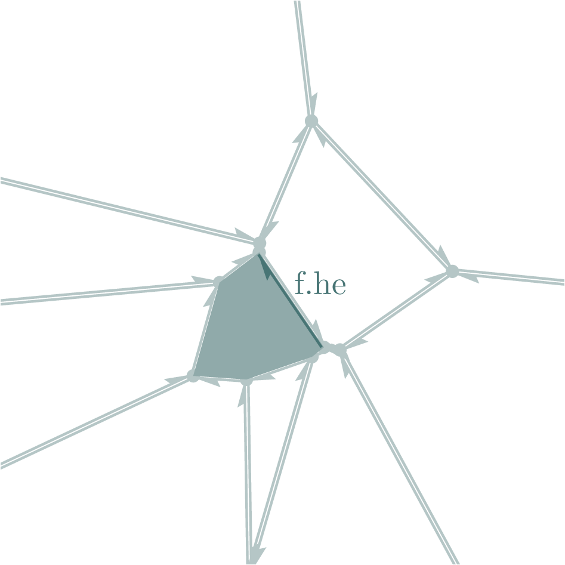

(a)

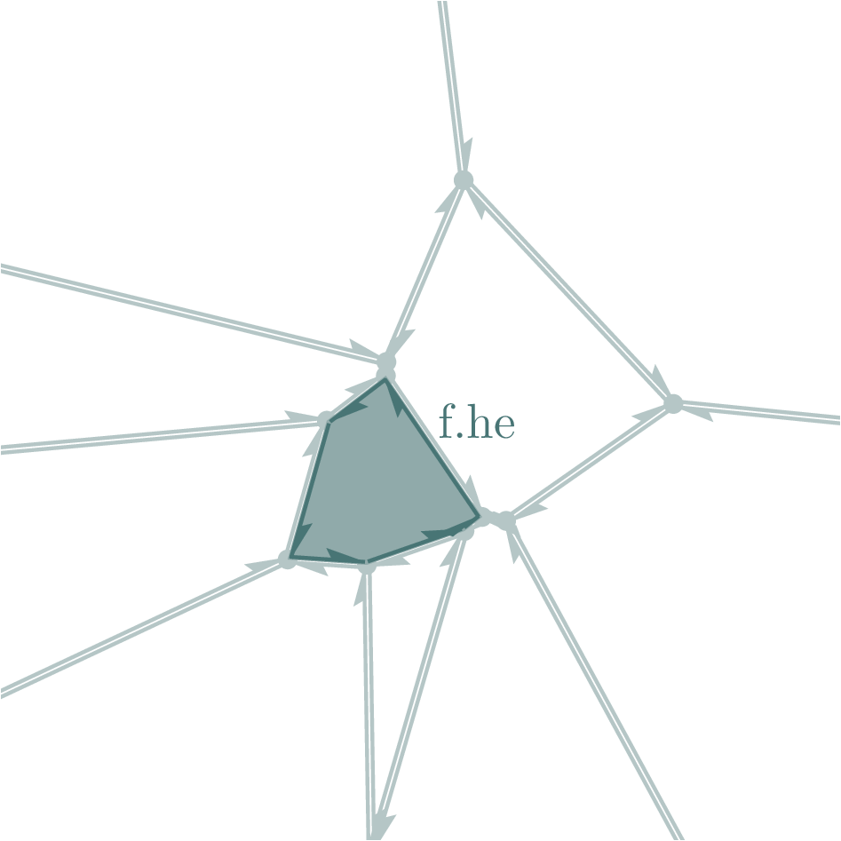

(b)

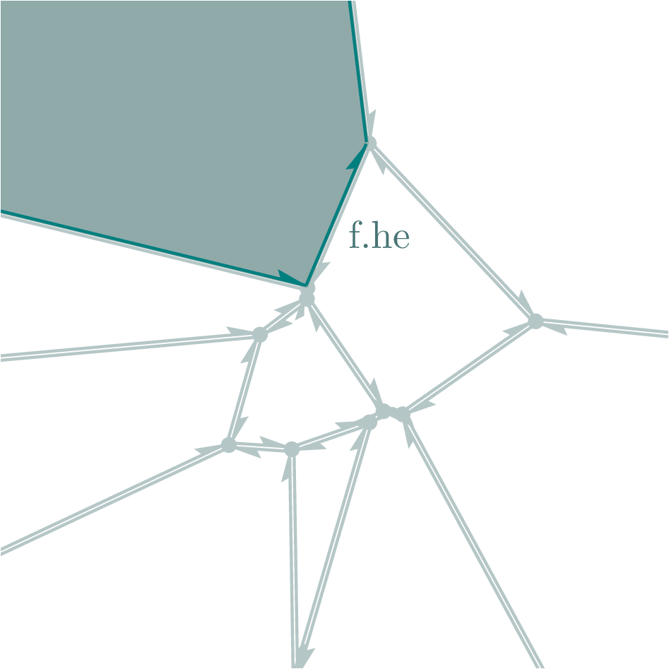

(c)

Figure 25: (a) Each face in a doubly-connected edge list includes a reference to any one half-edge along its boundary. By following the next and previous references from that one half-edge we can always trace out the entire boundary of the face. (b) If the face is closed then we can follow *either* the next or previous references until we return to the initial half-edge. (c) If the face is open then we have to follow *both* the next and previous half-edges until they we encounter an empty reference.

When working with more complex graphs, such as graphs containing disconnected faces or faces that are completely surrounded by other faces, we need to include additional half-edge references, such as one along the exterior boundary and one along each internal boundary. Because Voronoi graphs do not exhibit these topological features, however, we won’t need to worry about this additional information here.

### 4.1.4 Satellite Data

Depending upon the application the half-edge, vertex, and face data structures can also include additional information in the form of **satellite data**. For example when using a doubly-connected edge list to represent a Voronoi graph it will be helpful to include information about the associated sites, three for each vertex object and one for each face object. Note that we don’t need to store the two sites associated with an edge; this information can be recovered from the sites of the left faces of the corresponding half-edges.

### 4.1.5 Bounding Box and Pseudo-Vertices

The visualization of Voronoi graphs is easier if we add a few more objects to the doubly-connected edge list data structure. In particular, a natural addition is the configuration of a bounding box as well as **pseudo-vertices** along that bounding box that can be used to terminate any dangling half-edges. This ensures, for example, that every half-edge includes a non-empty originating vertex references which in turns makes visualization functions more uniform.

## 4.2 Implementing Beach Lines

A beach line consists of parabolic arcs and the breakpoints that separate them. Critically these objects exhibit a consistent *ordering*.

As we work through Fortune’s algorithm we will need to be able to efficiently search through these ordered objects. Moreover, we need to be able to add and remove arcs and breakpoints without disrupting the ordering. Conveniently all of these operations can be implemented with a slightly modified **binary search tree** (Cormen et al. 2022) that lacks an explicit key.

Many references, in particular Berg et al. (2008), recommend a binary search tree with two types of nodes: one to represent arcs and one to represent the breakpoints. Unfortunately this representation introduces some awkward implementation problems that are poorly documented. Your humble author has not yet been able to work these issues out.

In this note I will adopt a different representation inspired by, although slightly different from, the approach taken in [pvigier’s blog](https://pvigier.github.io/2018/11/18/fortune-algorithm-details.html). Here beach lines will be implemented with a binary search tree where every node represents an arc and its lower breakpoint paired together (Figure 26).

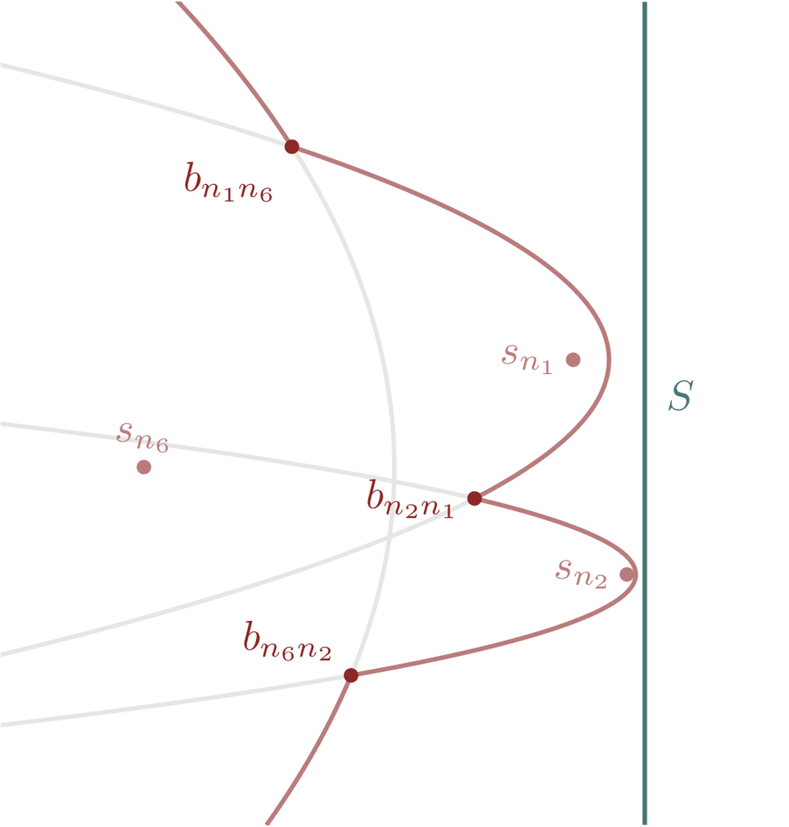

(a)

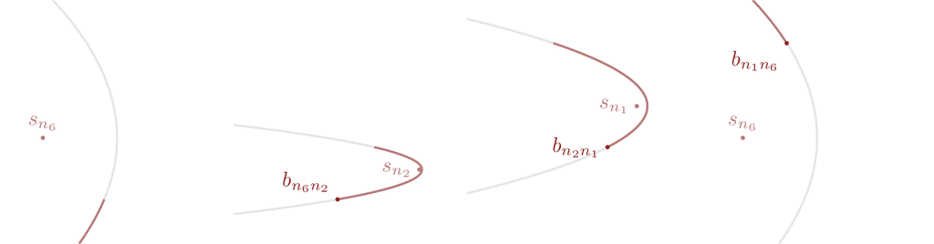

(b)

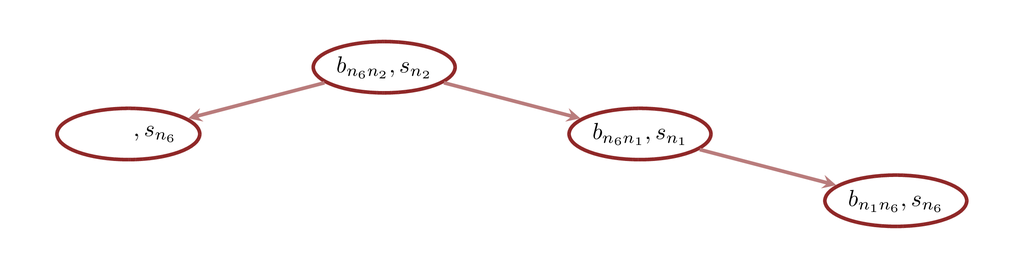

(c)

Figure 26: (a) Every beach line (b) can be decomposed into a collection of ordered arc and lower breakpoint pairs. (c) These ordered arc/breakpoint pairs can then implemented with a key-less binary search tree data structure.

Beyond a reference to their parent and child nodes in the tree, each nodes contains satellite data that allows us to reconstruct the local structure of the beach line for any sweep line configuration, and hence implement the sequential updates in Fortune’s algorithm.

### 4.2.1 Node Data

Each node in a beach line tree includes a reference to the site that generates the corresponding arc. Because the parabola generated by a single site can contribute to the beach line multiple times, multiple nodes can share the same site reference.

Once we know the generating site we can dynamically compute the shape of the arc for any position of the sweep line. If we also know the position of the neighboring breakpoints we can then plot the full extent of the arc in the beach line.

To that end the site information is complemented with a reference to the Voronoi half-edge that originates from the lower breakpoint. From that reference we can derive the sites associated with the Voronoi edge, in particular from the left face of the half-edge and the left face of its twin. In turn those sites allow us to compute the intersection of the corresponding parabolas, and hence the position of the lower breakpoint.

Because the first arc in a beach line is always unbounded below, it does not feature a lower breakpoint. Consequently the smallest node in any beach line tree will always feature an empty half-edge reference. Every other node, however, will feature a non-trivial reference.

As the sweep line progresses the half-edges associated with each breakpoint will not yet have an originating Voronoi vertex. For visualization purposes we can always display these half-edges as if they originated from the current position of the corresponding breakpoint (Figure 27).

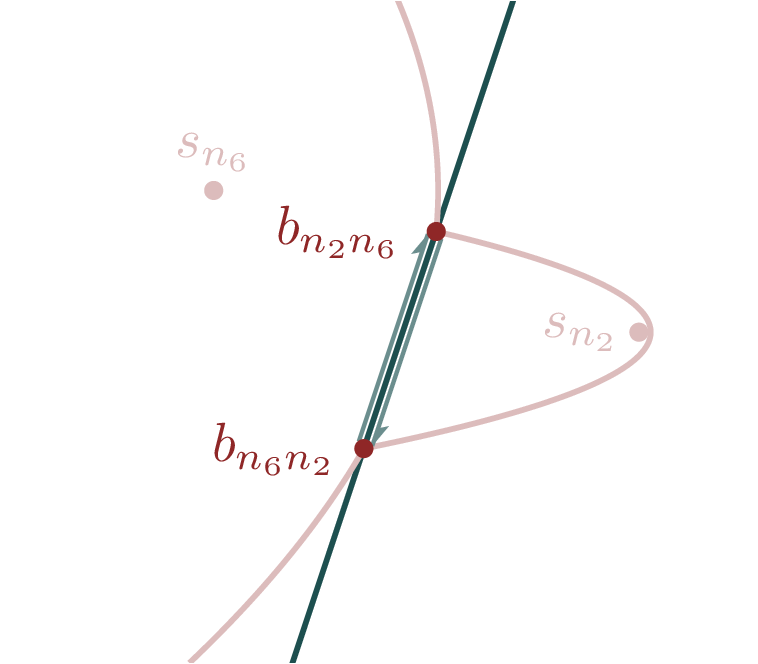

Figure 27: Initially the half-edges stored in each node are not anchored to any Voronoi vertices. When visualizing the progression of Fortune’s algorithm we can instead anchor each half-edge to the current position of the corresponding breakpoint. This ensures that the half-edges always span at least a segment of full Voronoi edge, shown here in dark teal.

Finally, to avoid repeated searches through the event queue each node also includes a reference to any vertex events that are centered on the corresponding arc. This allows us to, for example, quickly find events that need to be removed from the event queue when an arc is removed from the beach line.

### 4.2.2 Tree Operations

Beach line trees share most of the same operations as standard binary search trees, such as predecessor, successor, and deletion operations. Without static keys, however, beach line trees do not feature traditional key search or key insertion operations. In order to implement Fortune’s algorithm we need to introduce slight different versions of these operations.

For example Fortune’s algorithm requires an **arc search** where we find the arc in a beach line that intersects with a particular vertical position $y$ when the sweep line is at position $S$. To find the corresponding arc node in a beach line tree we can modify the standard key search operation, comparing $y$ to dynamically-computed breakpoint heights at each step instead of keys (Figure 28).

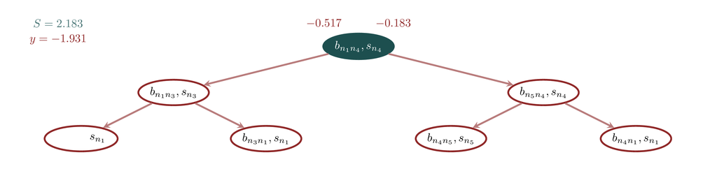

(a)

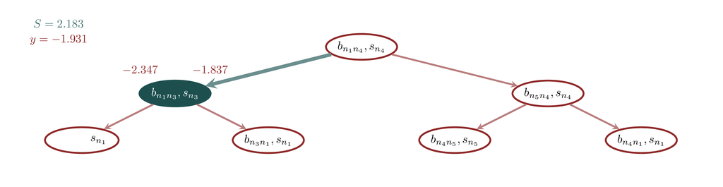

(b)

Once we find an appropriate node we then need to be able to insert nodes immediately before or after it, expanding the beach line with a new arc and breakpoint. Fortunately these **insert-before** and **insert-after** operations are straightforward to implement (Figure 29).

For example to insert a new node after an existing node we check to see if it has a right child. If it does not then we can insert the new node as the existing node’s right child. If there is a right child then we find the successor to the existing node, which will always have no left child otherwise it would not be a proper successor. Then we can insert the new node in that empty left child position.

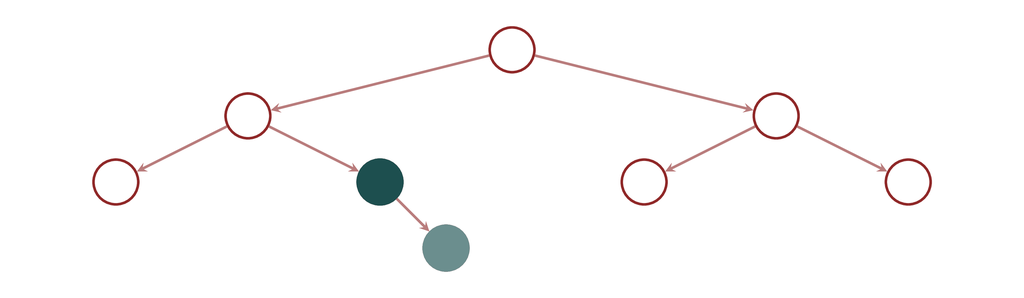

(a)

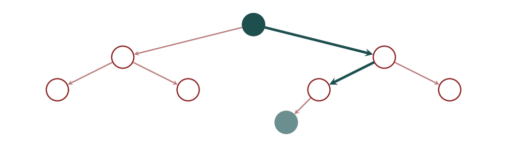

(b)

### 4.2.3 Balancing

The number of operations needed to implement all of these beach line tree operations scales with the height of a particular tree. Now the height of most trees scales logarithmically with the number of nodes, with in the context of Fortune’s algorithm also scales logarithmically with the number of sites. Consequently for most trees these operations require only a logarithmic number of operations, and a *typical* evaluation of Fortune’s algorithm will achieve an overall $N \log N$ cost scaling.

Unfortunately the height of *every* possible binary tree is not always logarithmic in the number of nodes. In the worst case the height of a tree can be linear in the number of nodes, pushing up the overall cost scaling of Fortune’s algorithm to quadratic.

In order to realize the optimal performance of Fortune’s algorithm we need to be able to avoid excessively tall, or **unbalanced** trees. Conveniently this can be accomplished with the use of **self-balancing binary trees**, in particular **red-black trees** (Cormen et al. 2022). These data structures modify the standard insertion and deletion operations to ensure that nodes are well-distributed across the entire tree.

With the use of red-black trees and balanced insertion and deletion operations we can ensure $N \log N$ cost scaling for any evaluation of Fortune’s algorithm.

## 4.3 The Event Queue

The event queue in Fortune’s algorithm can be efficiently implemented with a **priority queue** data structure (Cormen et al. 2022). Priority queues are equipped with an operation for “popping” the next element off of the queue as well as operations for inserting and deleting elements while maintaining the overall order of the elements.

To implement Fortune’s algorithm we’ll need to consider two types of events. Vertex events contain the position of the sweep line where an arc will collapse and a reference to the node in the beach line tree that represents that arc. Site events, on the other hand, contain the position where sweep line will encounter a new site as well as a reference to that site.

## 4.4 Event Processing

Fortune’s algorithm proceeds by popping the next event off of the event queue, using that event to advanced the sweep line, and then updating the Voronoi graph as necessary. With the operations of doubly-connected edge lists and binary search trees, processing each event is relatively straightforward.

### 4.4.1 Processing Site Events

Processing a site event begins by using the arc search operation of the beach line tree to find the arc that intersects with the height of the new site by searching through the beach line tree.

Because splitting this arc will invalidate any existing vertex event centered on it, we have to remove any corresponding vertex event from the event queue. This is straightforward given the vertex event reference held in each node.

As the sweep line passes the new site, the intersecting arc will split into three arcs, with two new breakpoints between them (Figure 30 (a), Figure 30 (b)). This expansion is implemented by creating two new nodes, one associated with the new site and one with the site generating the existing arc, and then inserting them into the beach line tree with two balanced insert-after operations (Figure 30 (c)).

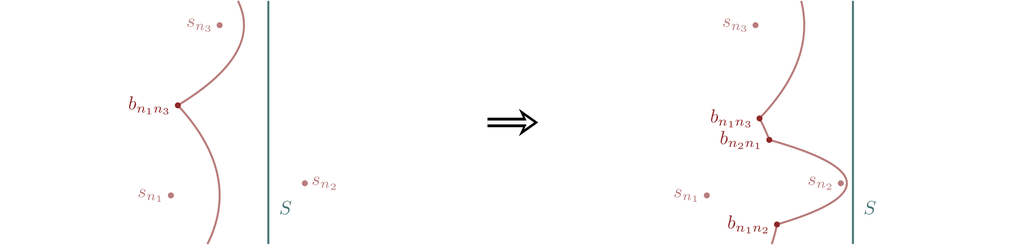

(a)

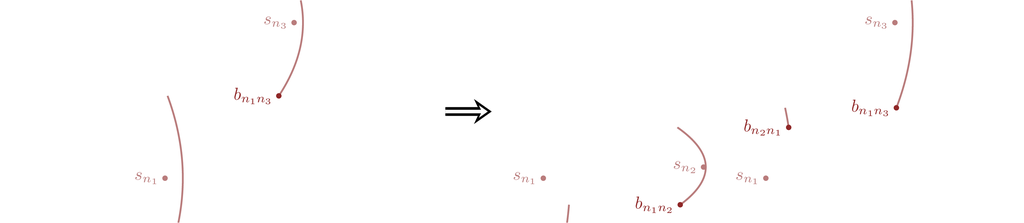

(b)

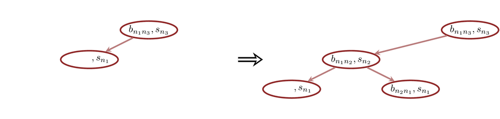

(c)

Figure 30: (a) A site event splits one of the arcs in the initial beach line into three arcs, with two new breakpoints. (b) This corresponds to two new arc-breakpoint pairs being introduced. (c) The addition of the two new arc-breakpoint pairs is readily implemented by twice applying the insert-after operation to the initial beach line tree.

The half-edges of these two new nodes are always twinned to each other (Figure 31). Together the half-edges define a new Voronoi edge associated with the old and new sites.

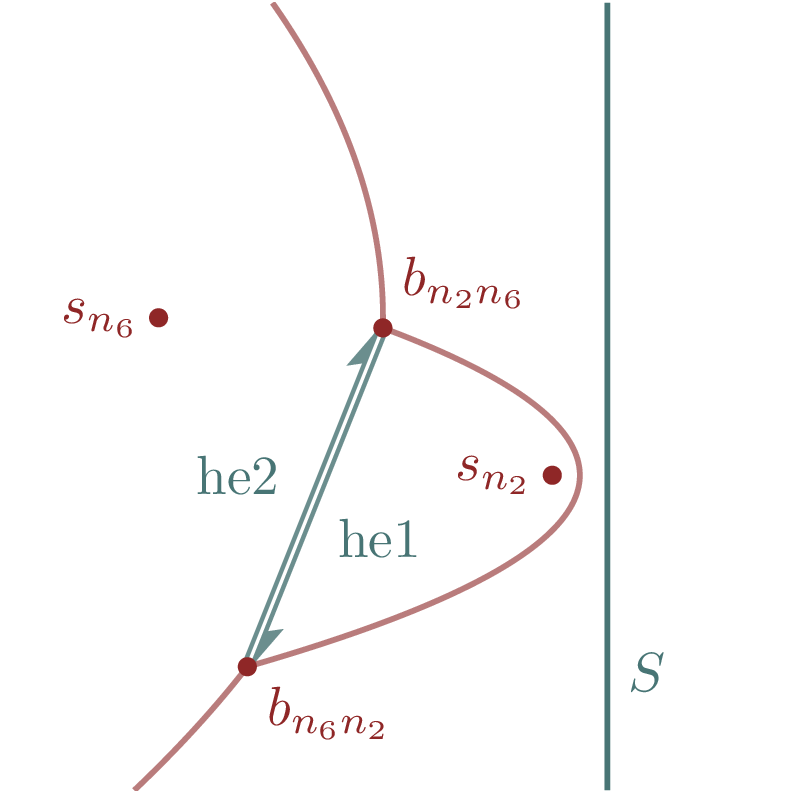

Figure 31: The introduction of a new site introduces a new Voronoi edge which is implemented with two new half-edges in the Voronoi graph that are twinned with each other. A reference to each of these half-edges is stored in the the two new nodes added to the beach line tree. For example here a reference to the half-edge `he1` is stored in the node $(b_{n_{6} n_{2}}, s_{n_{2}})$ while a reference to `he2` is stored in the node $(b_{n_{2} n_{6}}, s_{n_{6}})$.

Lastly incorporating the new site creates up to two new triplets of neighboring arcs that might generate new vertex events. Fortunately the nodes in the beach line tree representing these new triplets can be readily accessed with the predecessor and successor beach line operations.

### 4.4.2 Processing Vertex Events

The first step when processing a new vertex event is to remove any other vertex events that will become invalid after we remove the collapsing arc. This can be done efficiently by using the predecessor and successor operations of the beach line tree to find the neighboring arcs, and then removing any vertex events referenced in those arcs.

Next we manage the expansion of the Voronoi graph. We begin by adding a new vertex to the doubly-connected edge list at the point where the collapsing arc becomes singular and the neighboring breakpoints intersect.

Then we have to deal with the Voronoi edges. We create a new half-edge originating at the new vertex and its twin that, for the moment, is left unanchored (Figure 32). Lastly we have to carefully connect the previous and next references between these two new half-edges, the two half-edges associated with the neighboring breakpoints, and their twins (Figure 33).

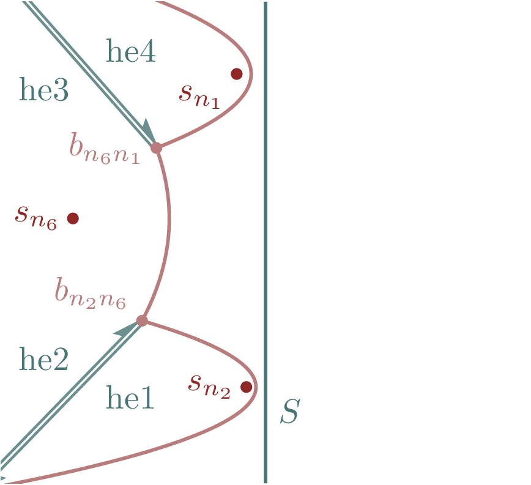

(a)

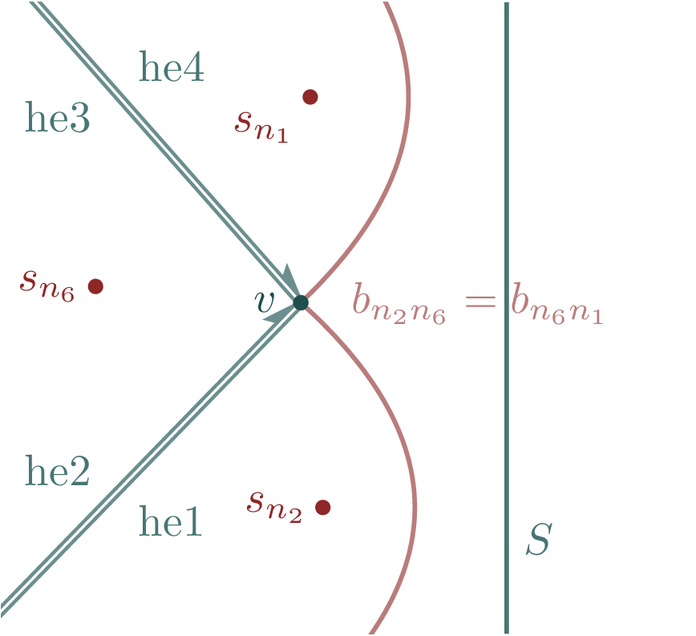

(b)

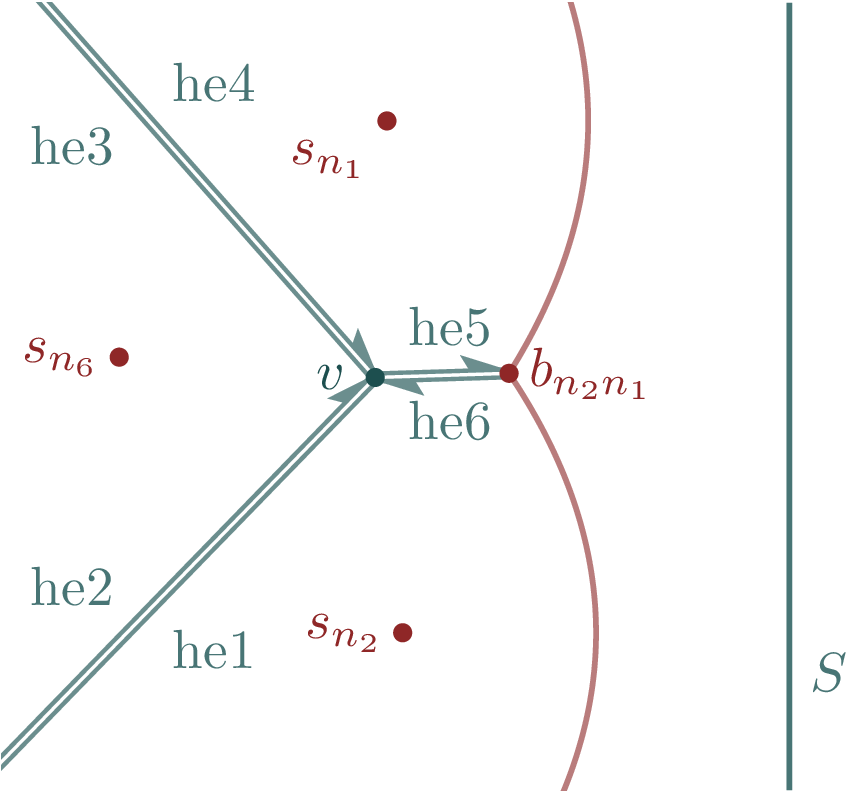

(c)

Figure 32: Vertex events require substantial updates to the half-edges of the Voronoi graph. (a) The breakpoints that merge in a vertex event contain references to two half-edges, here `he1` and `he3`. (b) When processing a vertex event we delete these references (c) Then we create two new half-edges, one of which is referenced by the new vertex, here `he5`, and one of which is referenced by the new breakpoint, here `he6`.

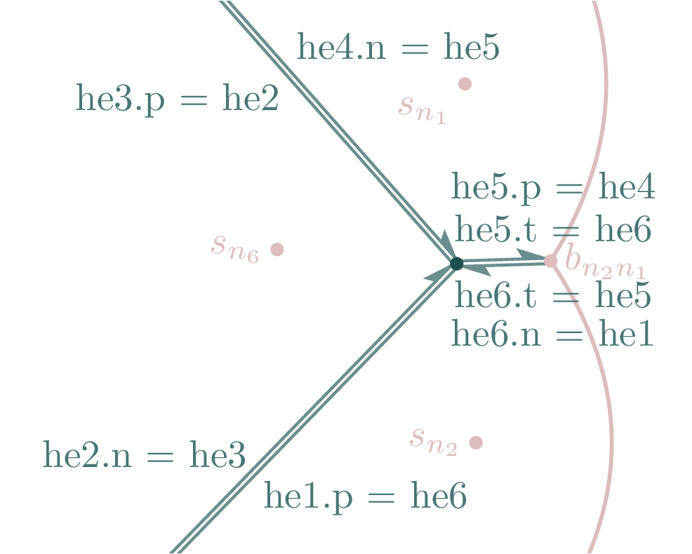

Figure 33: The trickiest part of processing a vertex event is making sure that the four existing half-edges and the two new half-edges all properly reference each other. These references ultimately define the structure of the Voronoi graph.

At this point we’re ready to remove the collapsing arc and replace its two neighboring breakpoints with a new merged breakpoint (Figure 34 (a), Figure 34 (b)). This can be done by updating the half-edge reference of the successor node and then applying a balanced deletion operation (Figure 34 (c)).

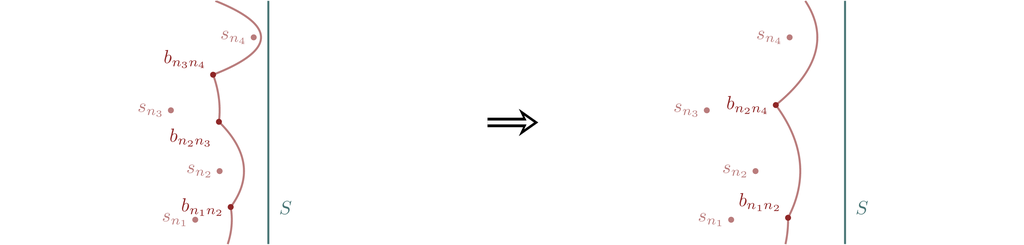

(a)

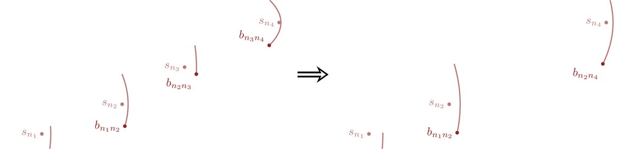

(b)

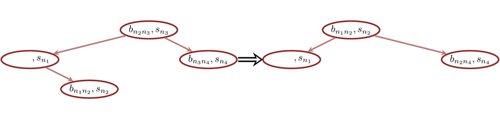

(c)

Figure 34: (a) A vertex event removes one of the arcs in the initial beach line, replacing the two neighboring breakpoints with a new merged breakpoint. (b) This corresponds to removing one of the initial arc-breakpoint pairs and then updating the breakpoint information in another arc-breakpoint pair. (c) The removal of the deprecated arc-breakpoint pair is implemented by applying the deletion operation to the initial beach line tree.

Lastly there are two new triplets of neighboring arcs that we have to check for possible new vertex events. Once again we can efficiently access these arcs by repeatedly applying the predecessor and successor beach line tree operations.

## 4.5 Clean Up

Once the event queue has been exhausted we are left with a doubly-connected edge list that contains all of the information about the Voronoi graph, and hence the Voronoi diagram.

At this point the beach line tree will *not* be empty. In fact the remaining breakpoint nodes reference all of the half-edges with unbounded origins. If we want to visualize the Voronoi graph neatly then we want to anchor these dangling edges by creating a bounding box and then adding a pseudo-vector to the doubly-connected edge list for the intersection of each dangling half-edge with that boundary.

# 5 Demonstration

To put all of this discussion into practice let’s work through a full implementation of Fortune’s algorithm in `R`. Although doubly-connected edge lists, binary search trees, and event queues can all be implemented with functional programming I strongly prefer a more object-oriented approach. To achieve object-oriented programming in `R` I will use `R6` classes (Chang 2025), at the cost of some clumsy interactions with base `R` graphics. At least using `R6` classes gets us pass-by-reference semantics for class instances instead of `R`’s usual call-by-need/lazy evaluation semantics!

```r
library(R6)
```

Speaking of graphics, let’s tweak the local graphics configuration.

```r
par(family="serif", las=1, bty="l",
    cex.axis=1, cex.lab=1, cex.main=1,
    xaxs="i", yaxs="i", mar = c(5, 5, 3, 1))

c_light <- c("#DCBCBC")
c_light_highlight <- c("#C79999")
c_mid <- c("#B97C7C")
c_mid_highlight <- c("#A25050")
c_dark <- c("#8F2727")
c_dark_highlight <- c("#7C0000")

c_light_teal <- c("#6B8E8E")
c_mid_teal <- c("#487575")
c_dark_teal <- c("#1D4F4F")
```

## 5.1 Beach Line

To define a beach line we’ll first need nodes.

This class implements arc-breakpoint nodes with satellite data for the associated site, half-edge, and vertex event. Note that the site variables are integer indices which will be used to access site information from global arrays.

The variable `red` denotes the coloring of the node which is used for balancing binary trees.

```r
node <- R6Class("node",
  public = list(
    site = NULL,
    parent = NULL,
    left = NULL,
    right = NULL,
    red = FALSE,
    id = NULL,
    he = NULL,  # Half-edge originating at (predecessor$site, site)
    scheduled_vertex = NULL,
    initialize = function(beachline) {
      if (is.integer(beachline)) {
        self$id <- beachline
      } else {
        self$parent <- beachline$nil
        self$left <- beachline$nil
        self$right <- beachline$nil

        beachline$last_node_id <- beachline$last_node_id + 1
        self$id <- beachline$last_node_id
      }
    }
  )
)
```

The `id` variable allows us to determine if any two `node` instances refer to the same object. In many programming languages this is done by directly comparing memory addresses, but because `R6` classes are built up from `R` environments this is not possible here.

```r
`==.node` = function(x, y) { x$id == y$id }
`!=.node` = function(x, y) { x$id != y$id }
```

A beach line tree itself is defined by its root node. Here we’ll be using a self-balancing red-black binary tree which uses the coloring of the nodes to limit the height of any given tree. Red-black binary trees requires a dedicated null, or nil, node.

```r
beachline <- R6Class("beachline",
  public = list(
   nil = NULL,
   root = NULL,
   last_node_id = NULL,
   initialize = function() {
     self$nil <- node$new(as.integer(0))
     self$root <- self$nil
     self$last_node_id <- as.integer(1)
   }
  ))
```

The `beachline` class also gives us a place to keep track of the node indices.

### 5.1.1 Black-Red Binary Tree Operations

The `insert_fixup` function balances a binary tree after we add the node `z`.

```r
beachline$set("private", "left_rotate",
function(x) {
  if (x$right == self$nil)
    return()

  y <- x$right
  x$right <- y$left

  if (y$left != self$nil)
    y$left$parent <- x

  y$parent <- x$parent

  if (x$parent == self$nil) {
    self$root <- y
  } else {
    if (x$parent$left == x)
      x$parent$left <- y
    else
      x$parent$right <- y
  }

  y$left <- x
  x$parent <- y
})
```

```r
beachline$set("private", "right_rotate",
function(x) {
  if (x$left == self$nil)
    return()

  y <- x$left
  x$left <- y$right

  if (y$right != self$nil)
    y$right$parent <- x

  y$parent <- x$parent

  if (x$parent == self$nil) {
    self$root <- y
  } else {
    if (x$parent$right == x)
      x$parent$right <- y
    else
      x$parent$left <- y
  }

  y$right <- x
  x$parent <- y
})
```

```r
beachline$set("private", "insert_fixup",
function(z) {
  while (z$parent$red) {
    if (z$parent == z$parent$parent$left) {
      y <- z$parent$parent$right
      if (y$red) {
        z$parent$red <- FALSE
        y$red <- FALSE
        z$parent$parent$red <- TRUE
        z <- z$parent$parent
      } else {
        if (z == z$parent$right) {
          z <- z$parent
          private$left_rotate(z)
        }
        z$parent$red <- FALSE
        z$parent$parent$red <- TRUE
        private$right_rotate(z$parent$parent)
      }
    } else {
      y <- z$parent$parent$left

      if (y$red) {
        z$parent$red <- FALSE
        y$red <- FALSE
        z$parent$parent$red <- TRUE
        z <- z$parent$parent
      } else {
        if (z == z$parent$left) {
          z <- z$parent
          private$right_rotate(z)
        }
        z$parent$red <- FALSE
        z$parent$parent$red <- TRUE
        private$left_rotate(z$parent$parent)
      }
    }
  }
  self$root$red <- FALSE
})
```

The `insert_fixup` function then allows us to implement balanced `insert-before` and `insert-after` operations.

```r
beachline$set("public", "insert_before",
function(x, y) {
  if (x$left == self$nil) {
    x$left <- y
    y$parent <- x
  } else {
    z <- self$predecessor(x)
    z$right <- y
    y$parent <- z
  }

  y$left <- self$nil
  y$right <- self$nil
  y$red <- TRUE

  private$insert_fixup(y)
})
```

```r
beachline$set("public", "insert_after",
function(x, y) {
  if (x$right == self$nil) {
    x$right <- y
    y$parent <- x
  } else {
    z <- self$successor(x)
    z$left <- y
    y$parent <- z
  }

  y$left <- self$nil
  y$right <- self$nil
  y$red <- TRUE

  private$insert_fixup(y)
})
```

Deleting a node from a red-black tree takes some care. To properly remove a node we’ll need to be able to calculate the boundaries of sub-trees.

```r
beachline$set("public", "min",
function(x) {
  if (x == self$nil)
    return(self$nil)
  while (x$left != self$nil)
    x <- x$left
  x
})
```

```r
beachline$set("public", "max",
function(x) {
  if (x == self$nil)
    return(self$nil)
  while (x$right != self$nil)
    x <- x$right
  x
})
```

Then we’ll need to carefully balance the tree.

```r
beachline$set("private", "transplant",
function(u, v) {
  if (u$parent == self$nil) {
    self$root <- v
  } else {
    if (u == u$parent$left) {
      u$parent$left <- v
    } else {
      u$parent$right <- v
    }
  }
  v$parent <- u$parent
})
```

```r
beachline$set("private", "delete_fixup",
function(x) {
  while (x != self$root && !x$red) {
    if (x == x$parent$left) {
      w <- x$parent$right

      if (w$red) {
        w$red <- FALSE
        x$parent$red <- TRUE
        private$left_rotate(x$parent)
        w <- x$parent$right
      }

      if (!w$left$red && !w$right$red) {
        w$red <- TRUE
        x <- x$parent
      } else {
        if (!w$right$red) {
          w$left$red <- FALSE
          w$red <- TRUE
          private$right_rotate(w)
          w <- x$parent$right
        }

        w$red <- x$parent$red
        x$parent$red <- FALSE
        w$right$red <- FALSE
        private$left_rotate(x$parent)
        x <- self$root
      }
    } else {
      w <- x$parent$left

      if (w$red) {
        w$red <- FALSE
        x$parent$red <- TRUE
        private$right_rotate(x$parent)
        w <- x$parent$left
      }

      if (!w$right$red && !w$left$red) {
        w$red <- TRUE
        x <- x$parent
      } else {
        if (!w$left$red) {
          w$right$red <- FALSE
          w$red <- TRUE
          private$left_rotate(w)
          w <- x$parent$left
        }

        w$red <- x$parent$red
        x$parent$red <- FALSE
        w$left$red <- FALSE
        private$right_rotate(x$parent)
        x <- self$root
      }
    }
  }
  x$red <- FALSE
})
```

```r
beachline$set("public", "delete",
function(z) {
  y <- z
  y_old_red <- y$red

  if (z$left == self$nil) {
    x <- z$right
    private$transplant(z, z$right)
  } else if (z$right == self$nil) {
    x <- z$left
    private$transplant(z, z$left)
  } else {
    y <- self$min(z$right)
    y_old_red <- y$red
    x <- y$right

    if (y != z$right) {
      private$transplant(y, y$right)
      y$right <- z$right
      y$right$parent <- y
    } else {
      x$parent <- y
    }

    private$transplant(z, y)
    y$left <- z$left
    y$left$parent <- y
    y$red <- z$red
  }

  if (!y_old_red)
    private$delete_fixup(x)
})
```

Neighboring nodes can be accessed with `precursor` and `successor` operations.

```r
beachline$set("public", "predecessor",
function(x) {
  if (x$left != self$nil) {
    return(self$max(x$left))
  } else {
    y <- x$parent
    while (   y != self$nil
              && x == y$left) {
      x <- y
      y <- y$parent
    }
    return(y)
  }
})
```

```r
beachline$set("public", "successor",
function(x) {
  if (x$right != self$nil) {
    return(self$min(x$right))
  } else {
    y <- x$parent
    while (   y != self$nil
           && x == y$right) {
      x <- y
      y <- y $parent
    }
    return(y)
  }
})
```

### 5.1.2 Visualization Functions

Visualizing the nodes in a binary search tree is particularly elegant with recursive functions. That said any function that interacts with base `R` graphics objects has to be external to the `R6` class.

```r
beachline$set("public", "height",
function(node=NULL) {
  if (is.null(node))
    node <- self$root

  if (node == self$nil)
    return(0)

  left_height <- self$height(node$left)
  right_height <- self$height(node$right)

  1 + max(left_height, right_height)
})
```

Just to minimize the text, we’ll display only the site that generates the arc associated with each node and not any information about the lower breakpoint.

```r
plot_node <- function(nil, node,
                      x, y,
                      delta_x, delta_y,
                      text_cex) {

  if (node$left != nil) {
    lines(c(x, x - delta_x), c(y, y - delta_y),
          col=c_mid_teal, lwd=2)
    plot_node(nil, node$left,
              x - delta_x, y - delta_y,
              delta_x / 2, delta_y, text_cex)
  }

  if (node$right != nil) {
    lines(c(x, x + delta_x), c(y, y - delta_y),
          col=c_mid_teal, lwd=2)
    plot_node(nil, node$right,
              x + delta_x, y - delta_y,
              delta_x / 2, delta_y, text_cex)
  }

  if (node$red)
    points(x, y, pch=16, col=c_dark, cex=3)
  else
    points(x, y, pch=16, col="black", cex=3)

  text(x, y, col="white", cex=text_cex,
       labels=node$site)
}
```

```r
plot_tree <- function(tree, delta=0.5, text_cex=0.75) {
  H <- tree$height()

  par(mar=c(0, 0, 0, 0))

  plot(NULL,
       xlab='', ylab='', xaxt="n", yaxt="n", frame.plot=F,
       xlim=c(-delta * (2**(H - 1) + 1), delta * (2**(H - 1) + 1)),
       ylim=c(-(H - 0.5) * delta, 0.5 * delta))

  plot_node(tree$nil, tree$root, 0, 0,
            delta * 2**(H - 2), delta, text_cex)
}
```

### 5.1.3 Fortune’s Algorithm Geometry Calculations

As we’ve seen, implementing Fortune’s algorithm requires a lot of geometric calculations.

For example we’ll need to be able to compute the vertical position of the breakpoint separating two neighboring arcs on a beach line. Site positions are accessed by indexing the global arrays `xs` and `ys`.

```r
beachline$set("public", "pair_intersection",
function(n1, n2, S) {
  if (xs[n1] == S)
    return(ys[n1])
  if (xs[n2] == S)
    return(ys[n2])

  a <- xs[n2] - xs[n1]
  b <- ys[n2] * (S - xs[n1]) - ys[n1] * (S - xs[n2])
  c <- (   ys[n2]**2 * (S - xs[n1])
         - ys[n1]**2 * (S - xs[n2])
         - (S - xs[n1]) * (S - xs[n2]) * (xs[n2] - xs[n1]) )

  e <- b / a
  d <- sqrt( e**2 - c / a )
  e - sign(a) * d
})
```

The horizontal position of a breakpoint can be recovered from the parabola defining each arc. Here `(fx, fy)` defines the focal point of the parabola and `S` the vertical directrix.

```r
beachline$set("public", "parabola_xs",
function(parabola_ys, fx, fy, S) {
  0.5 * ( (fx + S) - (parabola_ys - fy)**2 / (S - fx) )
})
```

We can’t forget the circumcircles.

```r
beachline$set("public", "circumcircle",
function(n1, n2, n3) {
  D <- 2 * (     xs[n1] * (ys[n2] - ys[n3])
               + xs[n2] * (ys[n3] - ys[n1])
               + xs[n3] * (ys[n1] - ys[n2]) )
  xc <- (    (xs[n1]**2 + ys[n1]**2) * (ys[n2] - ys[n3])
           + (xs[n2]**2 + ys[n2]**2) * (ys[n3] - ys[n1])
           + (xs[n3]**2 + ys[n3]**2) * (ys[n1] - ys[n2]) ) / D

  yc <- (    (xs[n1]**2 + ys[n1]**2) * (xs[n3] - xs[n2])
           + (xs[n2]**2 + ys[n2]**2) * (xs[n1] - xs[n3])
           + (xs[n3]**2 + ys[n3]**2) * (xs[n2] - xs[n1]) ) / D

  dx <- xc - xs[n1]
  dy <- yc - ys[n1]

  if (dx > dy) {
    r <- abs(dx) * sqrt(1 + (dy / dx)**2)
  } else {
    r <- abs(dy) * sqrt(1 + (dx / dy)**2)
  }

  c(xc, yc, r)
})
```

We can use these geometric functions to, for example, find the node representing the arc that intersects with a given vertical position.

```r
beachline$set("private", "arc_search",
function(z, y, S) {
  while (1) {
    z_left <- self$predecessor(z)
    if (z_left != self$nil) {
      by <- self$pair_intersection(z_left$site, z$site, S)
      if (y <= by) {
        z <- z$left
        next
      }
    }

    z_right <- self$successor(z)
    if (z_right != self$nil) {
      by <- self$pair_intersection(z$site, z_right$site, S)
      if (y > by) {
        z <- z$right
        next
      }
    }

    break
  }

  return(z)
})
```

### 5.1.4 Fortune’s Algorithm Event Functions

With all of these auxiliary functions we are finally ready to implement event processing functions.

One operating that appears over and over again when processing events is checking triplets of arcs to see if they define a valid vertex event and, if so, adding that event to the event queue `queue`.

As we discussed in Section 3.4.2 there is undoubtably a more elegant way to verify that `alpha` will collapse as the sweep line progresses than comparing `upper_int` to `lower_int`, but it will do for now.

```r
beachline$set("private", "schedule_new_vertex_event",
function(queue, alpha_l, alpha, alpha_r, S) {
  # Skip vertex if any of the neighboring arcs are nil
  if (alpha_l == self$nil || alpha_r == self$nil) {
    return()
  }

  # Skip vertex if any of the sites are the same
  if (alpha_l$site == alpha_r$site) {
    return()
  }

  # Construct circumcircle
  int <- self$circumcircle(alpha_l$site,
                           alpha$site,
                           alpha_r$site)
  S_new <- int[1] + int[3]


  lower_int <- self$pair_intersection(alpha_l$site,
                                      alpha$site, S_new)
  upper_int <- self$pair_intersection(alpha$site,
                                      alpha_r$site, S_new)

  if (   S_new > S
      && (abs(upper_int - lower_int) < (1e6 * .Machine$double.eps)) ) {
    vertex_event <- event$new(NULL, S_new, NULL, alpha)
    alpha$scheduled_vertex <- vertex_event
    queue$insert_event(vertex_event)
  }
})
```

Now we can process site events.

```r
beachline$set("private", "process_site_event",
function(queue, graph, new_event) {
  new_site <- new_event$site

  # Initialize beachline if empty
  if (self$root == self$nil) {
    self$root <- node$new(self)
    self$root$site <- new_site
    return()
  }

  # Find beachline arc that intersects
  # vertical position of new site
  alpha <- private$arc_search(self$root,
                              ys[new_site],
                              new_event$x)

  # Delete any scheduled vertex
  # events at intersecting arc
  if (!is.null(alpha$scheduled_vertex)) {
    queue$delete_event(alpha$scheduled_vertex)
    alpha$scheduled_vertex <- NULL
  }

  # Split intersecting arc
  alpha_r <- node$new(self)
  alpha_r$site <- new_site

  self$insert_after(alpha, alpha_r)

  alpha_rr <- node$new(self)
  alpha_rr$site <- alpha$site

  self$insert_after(alpha_r, alpha_rr)

  # Instantiate and connect new half-edges
  new_he <- graph$new_half_edge(left_face=alpha$site)     # (alpha, alpha_r)
  new_he$twin <- graph$new_half_edge(left_face=new_site,  # (alpha_r, alpha_rr)
                                     twin=new_he)

  alpha_r$he <- new_he
  alpha_rr$he <- new_he$twin

  # Attempt to schedule vertex events
  # for the two new arc triplets
  alpha_l <- self$predecessor(alpha)
  private$schedule_new_vertex_event(queue,
                                    alpha_l, alpha, alpha_r,
                                    new_event$x)

  alpha_rrr <- self$successor(alpha_rr)
  private$schedule_new_vertex_event(queue,
                                    alpha_r, alpha_rr, alpha_rrr,
                                    new_event$x)
})
```

Vertex event processing follows.

```r
beachline$set("private", "process_vertex_event",
function(queue, graph, new_event) {
  alpha <- new_event$arc

  alpha_r <- self$successor(alpha)
  alpha_rr <- self$successor(alpha_r)

  alpha_l <- self$predecessor(alpha)
  alpha_ll <- self$predecessor(alpha_l)

  # Clean up deprecated vertex events in the queue
  if (!is.null(alpha_r$scheduled_vertex)) {
    queue$delete_event(alpha_r$scheduled_vertex)
    alpha_r$scheduled_vertex <- NULL
  }

  if (!is.null(alpha_l$scheduled_vertex)) {
    queue$delete_event(alpha_l$scheduled_vertex)
    alpha_l$scheduled_vertex <- NULL
  }

  # Create vertex
  int <- self$circumcircle(alpha_l$site, alpha$site, alpha_r$site)
  v <- vertex$new(int[1:2], alpha_l$site, alpha$site, alpha_r$site)
  graph$add_vertex(v)

  # Connect vertex
  alpha_r$he$origin <- v
  alpha$he$origin <- v

  new_he <- graph$new_half_edge(origin=v,
                                left_face=alpha_r$site)
  new_he$twin <- graph$new_half_edge(left_face=alpha_l$site,
                                     twin=new_he)

  v$he <- new_he

  # Connect half-edges
  alpha$he$twin$nxt <- alpha_r$he
  alpha_r$he$prv <- alpha$he$twin

  alpha_r$he$twin$nxt <- new_he
  new_he$prv <- alpha_r$he$twin

  new_he$twin$nxt <- alpha$he
  alpha$he$prv <- new_he$twin

  # Update active half-edges
  alpha_r$he <- new_he$twin

  # Delete deprecated arcs
  self$delete(alpha)

  # Check for new vertex events
  private$schedule_new_vertex_event(queue,
                                    alpha_ll, alpha_l, alpha_r,
                                    new_event$x)

  private$schedule_new_vertex_event(queue,
                                    alpha_l, alpha_r, alpha_rr,
                                    new_event$x)
})
```

Lastly we’ll wrap both of these event processing functions together.

```r
beachline$set("public", "process_next_event",
function(queue, graph) {
  next_event <- queue$pop_next_element()

  if (!is.null(next_event$site)) {
    private$process_site_event(queue,
                               graph,
                               next_event)
  } else {
    private$process_vertex_event(queue,
                                 graph,
                                 next_event)
  }
})
```

### 5.1.5 Fortune’s Algorithm Visualization Functions

To monitor the progress of Fortune’s algorithm we’ll define some functions that allow us to plot the shape of the beach line for any sweep line position, as well as the behavior of any preliminary Voronoi edges.

```r
plot_arcs <- function(bl, S, x=NULL, y_min, y_max) {
  if (is.null(x))
    x <- bl$root

  if (x == bl$nil)
    return(y_max)

  # Recurse right
  y_max <- plot_arcs(bl, S, x$right, y_min, y_max)

  # Plot arc
  if (is.null(x$he)) {
    # Plot parabola
    if (y_min + 1e-3 < y_max) {
      parabola_ys <- seq(y_min, y_max, 1e-3)
      lines(bl$parabola_xs(parabola_ys, xs[x$site], ys[x$site], S),
            parabola_ys, lty=2, lwd=2, col=c_mid)
    }
  } else {
    # Compute left breakpoint
    by <- bl$pair_intersection(x$he$left_face, x$site, S)
    bx <- bl$parabola_xs(by, xs[x$site], ys[x$site], S)

    # Plot parabola
    if (by + 1e-3 < y_max) {
      parabola_ys <- seq(by, y_max, 1e-3)
      lines(bl$parabola_xs(parabola_ys, xs[x$site], ys[x$site], S),
            parabola_ys, lty=2, lwd=2, col=c_mid)
    }

    # Plot left breakpoint
    points(bx, by, col=c_light, pch=16)
    text(bx + 0.1, by,
        labels=paste0(x$he$left_face, ",", x$site))

    # Save breakpoint position for plotting half-edges
    x$he$pseudo_origin <- c(bx, by)

    # Update upper bound
    y_max <- by
  }

  # Recurse left
  y_max <- plot_arcs(bl, S, x$left, y_min, y_max)

  return(y_max)
}
```

```r
plot_beachline <- function(bl, S,
                           xlim=c(-4, 4),
                           ylim=c(-4, 4)) {

  plot(xs, ys, col=c_dark, pch=16,
       xlim=xlim, ylim=ylim,
       main="")

  # Plot sweep line
  abline(v=S, col=c_mid_teal, lty=2)

  # Plot site parabolas given the sweep line
  for (i in which(xs < S)) {
    text(xs[i] + 0.1, ys[i], i)
    parabola_ys <- seq(ylim[1], ylim[2], 0.01)
    lines(bl$parabola_xs(parabola_ys, xs[i], ys[i], S),
          parabola_ys, lwd=2, col="#DDDDDD")
  }

  # Plot beach line
  if (bl$root != bl$nil)
    r <- plot_arcs(bl, S, y_min=ylim[1], y_max=ylim[2])
}
```

```r
plot_beachline_half_edges <- function(bl, S, x=NULL,
                                      lwd=2, col=c_mid_teal,
                                      delta=0.08, eps=0.04,
                                      theta=60, gamma=0.0075) {
  if (is.null(x))
    x <- bl$root

  if (x != bl$nil) {
    # Recurse right
    plot_beachline_half_edges(bl, S, x$right,
                              lwd, col, delta,
                              eps, theta, gamma)

    # Plot arc
    if (!is.null(x$he)) {
      if (is.null(x$he$origin)) p1 <- x$he$pseudo_origin
      else                      p1 <- x$he$origin$pos

      if (is.null(x$he$twin$origin)) p2 <- x$he$twin$pseudo_origin
      else                           p2 <- x$he$twin$origin$pos

      plot_half_edge(p1, p2, lwd, col, delta, eps, theta, gamma)
    }

    # Recurse left
    plot_beachline_half_edges(bl, S, x$left,
                              lwd, col, delta,
                              eps, theta, gamma)
  }
}
```

## 5.2 Event Queue

We’ll overload the `event` class to handle both site and vertex events at the same time. The variable `site` is used for only site events while the variable `arc` is used for only vertex events.

```r
event <- R6Class("event",
  public=list(
  x=NULL,
  site=NULL,
  arc=NULL,
  queue_idx=NULL,
  initialize = function(i, x, site, arc) {
    self$queue_idx <- i
    self$x <- x
    self$site <- site
    self$arc <- arc
  }))
```

The event queue itself is a pretty straightforward implementation of a priority queue data structure. When creating a new event queue instance we pass in a vector of indices for the available sites which are then used to create the site events that initially populate the queue.

```r
event_queue <- R6Class("event_queue",
  public=list(
   idxs=NULL,
   events=NULL,
   length=0,
   initialize = function(sites, xs) {
     self$length <- length(sites)
     self$idxs <- 1:self$length
     for (i in seq_along(sites)) {
       new_event <- event$new(i, xs[i], i, NULL)
       self$events <- append(self$events,
                             new_event)
     }
     for (i in (self$length %/% 2):1) {
       private$min_heapify(i)
     }
   },
   is_empty = function() {
     self$length == 0
   },
   is_not_empty = function() {
     self$length > 0
   }))
```

```r
event_queue$set("private", "min_heapify",
function(i) {
  l <- 2 * i
  r <- l + 1

  if (   l <= self$length
      &&   self$events[[self$idxs[l]]]$x
         < self$events[[self$idxs[i]]]$x) {
    smallest <- l
  } else {
    smallest <- i
  }

  if (   r <= self$length
         &&   self$events[[self$idxs[r]]]$x
         < self$events[[self$idxs[smallest]]]$x) {
    smallest <- r
  }

  if (smallest != i) {
    n <- self$events[[self$idxs[i]]]$queue_idx
    self$events[[self$idxs[i]]]$queue_idx <-
      self$events[[self$idxs[smallest]]]$queue_idx
    self$events[[self$idxs[smallest]]]$queue_idx <- n

    n <- self$idxs[i]
    self$idxs[i] <- self$idxs[smallest]
    self$idxs[smallest] <- n

    private$min_heapify(smallest)
  }
})
```

```r
event_queue$set("public", "insert_event",
function(new_event) {
  self$length <- self$length + 1
  self$idxs <- c(self$idxs, length(self$events) + 1)

  new_event$queue_idx <- self$length
  self$events <- append(self$events, new_event)

  i <- self$length
  while (   i > 1
            &&   self$events[[self$idxs[i %/% 2]]]$x
            > self$events[[self$idxs[i]]]$x) {
    n <- self$events[[self$idxs[i]]]$queue_idx
    self$events[[self$idxs[i]]]$queue_idx <-
      self$events[[self$idxs[i %/% 2]]]$queue_idx
    self$events[[self$idxs[i %/% 2]]]$queue_idx <- n

    n <- self$idxs[i]
    self$idxs[i] <- self$idxs[i %/% 2]
    self$idxs[i %/% 2] <- n

    i <- i %/% 2
  }
})
```

```r
event_queue$set("public", "insert_site_event",
function(site, xs) {
  self$insert_event(event$new(NULL, xs[site], site, NULL))
})
```

```r
event_queue$set("public", "insert_vertex_event",
function(S, arc) {
  self$insert_event(event$new(NULL, S, NULL, arc))
})
```

```r
event_queue$set("public", "pop_next_element",
function() {
  if (self$length == 0) {
    print("The queue is empty!")
    return(NULL)
  }

  next_element <- self$events[[self$idxs[1]]]

  self$idxs[1] <- self$idxs[self$length]
  self$events[[self$idxs[1]]]$queue_idx <- 1

  self$idxs <- self$idxs[-self$length]
  self$length <- self$length - 1

  private$min_heapify(1)

  next_element
})
```

```r
event_queue$set("public", "delete_event",
function(event) {
  event$x <- self$events[[self$idxs[1]]]$x - 1

  i <- event$queue_idx
  while (   i > 1
         &&   self$events[[self$idxs[i %/% 2]]]$x
            > self$events[[self$idxs[i]]]$x) {
    n <- self$events[[self$idxs[i]]]$queue_idx
    self$events[[self$idxs[i]]]$queue_idx <-
      self$events[[self$idxs[i %/% 2]]]$queue_idx
    self$events[[self$idxs[i %/% 2]]]$queue_idx <- n

    n <- self$idxs[i]
    self$idxs[i] <- self$idxs[i %/% 2]
    self$idxs[i %/% 2] <- n

    i <- i %/% 2
  }
  e <- self$pop_next_element()
})
```

```r
event_queue$set("public", "check_min_heapify",
function() {
  if (self$length > 0) {
    for (i in 1:self$length)  {
      if (i %/% 2 == 0) next
      print(   self$events[[self$idxs[i %/% 2]]]$x
            <= self$events[[self$idxs[i]]]$x)
    }
  }
})
```

```r
event_queue$set("public", "next_event",
function() {
  if (self$length > 0)
    self$events[[self$idxs[1]]]
})
```

## 5.3 Doubly-Connected Edge List

In order to represent a Voronoi graph we’ll need classes for half_edges, vertices, and faces and then the doubly-connected edge list that encapsulates them.

Like the beach line nodes the half-edges uses a global indexing to allow for equality comparisons. The `pseudo_origin` variable is used for plotting dangling half-edges that have not yet been anchored to vertices.

```r
half_edge <- R6Class("half_edge",
  public=list(
   pseudo_origin=NULL,
   origin=NULL,
   left_face=NULL,
   twin=NULL,
   prv=NULL,
   nxt=NULL,
   visited=FALSE,
   id=NULL,
   initialize = function(graph, o, lf, t, p, n) {
     self$origin <- o
     self$left_face <- lf
     self$twin   <- t
     self$prv    <- p
     self$nxt    <- n

     graph$last_half_edge_id <- graph$last_half_edge_id + 1
     self$id <- graph$last_half_edge_id
   }))
```

```r
`==.half_edge` = function(x, y) { x$id == y$id }
`!=.half_edge` = function(x, y) { x$id != y$id }
```

```r
vertex <- R6Class("vertex",
  public=list(
    pos=NULL,
    n1=NULL,
    n2=NULL,
    n3=NULL,
    he=NULL,
    initialize = function(p, n1, n2, n3) {
      self$pos <- p
      self$n1 <- n1
      self$n2 <- n2
      self$n3 <- n3
    }))
```

```r
face <- R6Class("face",
  public=list(
    site=NULL,
    he=NULL,
    initialize = function(site, he) {
      self$site <- site
      self$he <- he
    }))
```

```r
dcel <- R6Class("dcel",
  public=list(
    vertices=NULL,
    pseudo_vertices=NULL,
    faces=NULL,
    xlim=NULL,
    ylim=NULL,
    last_half_edge_id = NULL,
    initialize = function() {
      self$vertices <- list()
      self$pseudo_vertices <- list()
      self$faces <- list()
      self$last_half_edge_id <- as.integer(1)
    },
    add_vertex = function(v) {
      self$vertices <-
        append(self$vertices, v)
    },
    N_vertices = function() {
      length(self$vertices)
    },
    add_pseudo_vertex = function(pv) {
      self$pseudo_vertices <-
        append(self$pseudo_vertices, pv)
    },
    N_pseudo_vertices = function() {
      length(self$pseudo_vertices)
    },
    add_face = function(f) {
      self$faces <-
        append(self$faces, f)
    },
    N_faces = function() {
      length(self$faces)
    }))
```

```r
dcel$set("public", "new_half_edge",
function(origin=NULL, left_face=NULL,
         twin=NULL, prv=NULL, nxt=NULL) {
  half_edge$new(self, origin, left_face, twin, prv, nxt)
})
```

There are all kinds of operations that we can implement from the structure encoded in a doubly-connected edge list. For example we can automatically compute a bounding box that contains all of the vertices. The parameter `q` specifies how much multiplicative margin we add around the smallest bounding box.

```r
dcel$set("public", "compute_bounding_box",
function(q=0.05) {
  # Set bounding box edges to
  # extreme vertex positions
  self$xlim <- c(self$vertices[[1]]$pos[1],
                 self$vertices[[1]]$pos[1])
  self$ylim <- c(self$vertices[[1]]$pos[2],
                 self$vertices[[1]]$pos[2])

  for (v in self$vertices[-1]) {
    if (v$pos[1] > self$xlim[2]) {
      self$xlim[2] <- v$pos[1]
    } else if (v$pos[1] < self$xlim[1]) {
      self$xlim[1] <- v$pos[1]
    }

    if (v$pos[2] > self$ylim[2]) {
      self$ylim[2] <- v$pos[2]
    } else if (v$pos[2] < self$ylim[1]) {
      self$ylim[1] <- v$pos[2]
    }
  }

  # Add proportional margins to bounding box
  dx <- self$xlim[2] - self$xlim[1]
  self$xlim[1] <- self$xlim[1] - q * dx
  self$xlim[2] <- self$xlim[2] + q * dx

  dy <- self$ylim[2] - self$ylim[1]
  self$ylim[1] <- self$ylim[1] - q * dy
  self$ylim[2] <- self$ylim[2] + q * dy
})
```

Given a bounding box we can then introduce pseudo-vertices to anchor any dangling half-edges.

```r
dcel$set("public", "anchor_dangling_edges",
function(z, xs, ys) {
  # Dangling edge
  he <- z$he

  if (!is.null(he)) {
    nu <- he$twin$origin$pos
    zeta <- -nu

    i_left <- he$left_face
    i_right <- he$twin$left_face
    dangling_he <- he

    # Anchored edges
    he <- he$nxt
    zeta <- zeta + he$twin$origin$pos

    he <- he$twin$nxt
    zeta <- zeta + he$twin$origin$pos

    # Compute bisecting vector in the opposite
    # direction of the anchored edges
    delta <- c(ys[i_right] - ys[i_left],
               xs[i_left]  - xs[i_right])

    # Compute closest bounding box intersection
    bh <- ifelse(delta[1] > 0, self$xlim[2], self$xlim[1])
    bv <- ifelse(delta[2] > 0, self$ylim[2], self$ylim[1])

    pv_x <- bh
    pv_y <- nu[2] + delta[2] * (pv_x - nu[1]) / delta[1]
    if (pv_y < self$ylim[1] || pv_y > self$ylim[2]) {
      pv_y <- bv
      pv_x <- nu[1] + delta[1] * (pv_y - nu[2]) / delta[2]
    }

    # Anchor dangling edge to a new pseudo-vertex
    # positioned at the bounding box intersection
    pv <- vertex$new(c(pv_x, pv_y), NULL, NULL, NULL)
    dangling_he$origin <- pv
    pv$he <- dangling_he
    self$add_pseudo_vertex(pv)

    # Recurse
    self$anchor_dangling_edges(z$left, xs, ys)
    self$anchor_dangling_edges(z$right, xs, ys)
  }
})
```

More relevant to the construction of a Voronoi diagrams, we also can follow the half-edges to automatically identify all of the faces in the graph, and hence cells in the diagram.

```r
dcel$set("private", "reset_visitation",
function() {
  for (v in self$vertices) {
    he <- v$he
    he$visited <- FALSE
    he$twin$visited <- FALSE
    he <- he$prv
    he$visited <- FALSE
    he$twin$visited <- FALSE
    he <- he$twin$prv
    he$visited <- FALSE
    he$twin$visited <- FALSE
  }
})
```

```r
dcel$set("public", "find_faces",
function(he=NULL) {

  if (is.null(he)) {
    private$reset_visitation()
    he <- self$vertices[[1]]$he
  }

  init_he <- he
  open_face <- FALSE
  closed_face <- FALSE

  while (!he$visited) {
    he$visited <- TRUE
    he <- he$nxt
    if (is.null(he)) {
      open_face <- TRUE
      break
    }
    if (he == init_he) {
      closed_face <- TRUE
      break
    }
  }

  he <- init_he
  if (open_face) {
    # Reverse to beginning of open boundary
    while(!is.null(he$prv)) {
      he <- he$prv
    }

    self$add_face(face$new(he$left_face, he))

    # Shoot along open boundary
    while(!is.null(he$nxt)) {
      if(!he$twin$visited) self$find_faces(he$twin)
      he <- he$nxt
    }
  }
  if (closed_face) {
    self$add_face(face$new(he$left_face, he))

    # Shoot along closed boundary
    while(1) {
      if(!he$twin$visited) self$find_faces(he$twin)
      he <- he$nxt
      if (he == init_he) break
    }
  }
})
```

Why spend all of this time creating graphs if we can’t visualize them with aesthetic flair?

```r
plot_half_edge <- function(pi, pf, lwd, col=c_mid_teal,
                           delta, eps, theta, gamma) {
  r <- pf - pi
  v <- r / sqrt(sum(r**2))

  r_perp <- c(r[2], -r[1])
  w <- r_perp / sqrt(sum(r_perp**2))

  # Perpendicular offset
  gammax <- -gamma * w[1]
  gammay <- -gamma * w[2]

  # Arrow body
  lines(c(pi[1], pf[1]) + gammax,
        c(pi[2], pf[2]) + gammay,
        lwd=lwd, col=col)

  # Arrow head
  phi_rad <- (90 - theta) * (3.14159265 / 180)
  p3 <- pf - (delta + eps * tan(phi_rad)) * v - eps * w
  p4 <- pf - delta * v

  polygon(c(pf[1], p3[1], p4[1], pf[1]) + gammax,
          c(pf[2], p3[2], p4[2], pf[2]) + gammay,
          col=col, border=NA)
}
```

```r
plot_vertex_edges <- function(v, lwd=2, ucol=c_mid_teal,
                              delta=0.1, eps=0.05,
                              theta=60, gamma=0.025) {
  points(v$pos[1], v$pos[2],
         pch=16, col=c_light_teal)

  he <- v$he

  while(1) {
    if (is.null(he$origin)) p1 <- he$pseudo_origin
    else                    p1 <- he$origin$pos

    if (is.null(he$twin$origin)) p2 <- he$twin$pseudo_origin
    else                         p2 <- he$twin$origin$pos

    plot_half_edge(p1, p2,
                   lwd, ifelse(he$visited, c_mid, ucol),
                   delta, eps, theta, gamma)

    he <- he$prv$twin
    if (is.null(he) || he == v$he) break
  }
}
```

```r
plot_face_boundary <- function(f, lwd=2, col=c_mid_teal,
                               delta=0.1, eps=0.05,
                               theta=60, gamma=0.025) {
  he <- f$he

  while (1) {
    points(he$origin$pos[1], he$origin$pos[2],
           pch=16, col=col)

    plot_half_edge(he$origin$pos, he$twin$origin$pos,
                   lwd, col,
                   delta, eps, theta, gamma)

    he <- he$nxt
    if (is.null(he) || he == f$he) break
  }
}
```

```r
plot_face <- function(f, col=c_mid_teal) {
  # Trace boundary
  he <- f$he

  perimeter_xs <- c()
  perimeter_ys <- c()

  while (1) {
    perimeter_xs <- c(perimeter_xs, he$origin$pos[1])
    perimeter_ys <- c(perimeter_ys, he$origin$pos[2])

    if (is.null(he$nxt)) {
      perimeter_xs <- c(perimeter_xs, he$twin$origin$pos[1])
      perimeter_ys <- c(perimeter_ys, he$twin$origin$pos[2])
      break
    }

    he <- he$nxt

    if (he == f$he) {
      # Close the perimeter
      perimeter_xs <- c(perimeter_xs, he$origin$pos[1])
      perimeter_ys <- c(perimeter_ys, he$origin$pos[2])
      break
    }
  }

  polygon(perimeter_xs, perimeter_ys, col=col, border=NULL)
}
```

## 5.4 Running Fortune’s Algorithm

Alright, let’s cut the pedagogical tension and finally build a Voronoi diagram.

We start by defining a collection of sites.

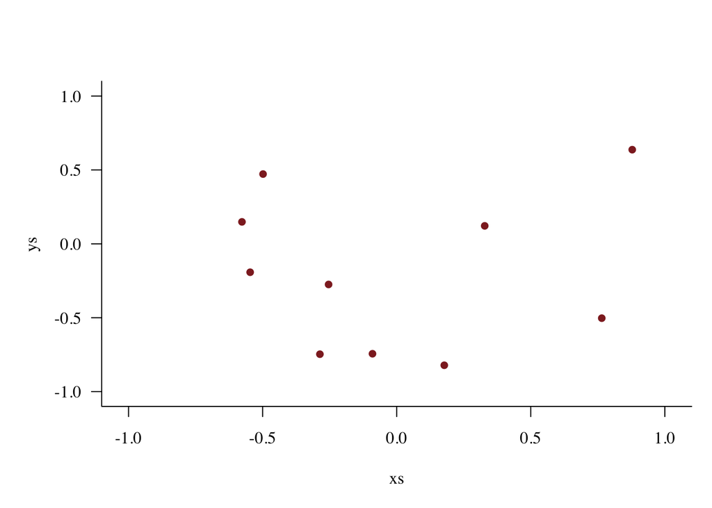

```r
N <- 10

set.seed(54482248)
xs <- runif(N, -1, 1)
ys <- runif(N, -1, 1)


par(mfrow=c(1, 1), mar=c(5, 5, 4, 1))
plot(xs, ys, col=c_dark, pch=16,
     xlim=c(-1.1, 1.1), ylim=c(-1.1, 1.1))
```

Next we initialize the event queue and beach line tree.

```r
queue <- event_queue$new(1:N, xs)

bl <- beachline$new()
voronoi <- dcel$new()

cat('Initial queue:\n')
```

```
Initial queue:
```

```r
for (i in queue$idxs) {
  arc <- queue$events[[i]]$arc
  if (is.null(queue$events[[i]]$arc)) {
    cat(paste('  S =', sprintf('%.3f', queue$events[[i]]$x), ':',
              'Site Event at', queue$events[[i]]$site), '\n')
  } else {
    cat(paste('  S =', sprintf('%.3f', queue$events[[i]]$x), ':',
              'Vertex Event at', queue$events[[i]]$arc$site), '\n')
  }
}
```

```
  S = -0.577 : Site Event at 6
  S = -0.546 : Site Event at 2
  S = -0.498 : Site Event at 1
  S = 0.177 : Site Event at 9
  S = -0.090 : Site Event at 10
  S = -0.286 : Site Event at 3
  S = -0.254 : Site Event at 7
  S = 0.328 : Site Event at 8
  S = 0.765 : Site Event at 4
  S = 0.878 : Site Event at 5
```

We can completely exhaust the event queue by running.

```r
while (queue$is_not_empty()) {
  bl$process_next_event(queue, voronoi)
}
```

Here, however, we’ll proceed a little bit more deliberately. This function processes the next event with extreme verbosity, communicating the type of the event, visualizing both the current beach line tree and the current beach line, and then displaying the status of the event queue.

```r
process_next_event <- function() {
  if (is.null(queue$next_event()$arc)) {
    cat(paste0('Processing Site Event (',
               queue$next_event()$site, ')\n'))
  } else {
    cat(paste('Processing Vertex Event (',
              queue$next_event()$arc$site, ')\n'))
  }

  bl$process_next_event(queue, voronoi)

  par(mfrow=c(2, 1))
  plot_tree(bl, text_cex=0.6)
  if (is.null(queue$next_event()$x)) {
    plot_beachline(bl, 2,
                   c(-4, 2), c(-2, 2))
    plot_beachline_half_edges(bl, S, col=c_dark_teal,
                              delta=0.08, eps=0.04, gamma=0.02)
    for (v in voronoi$vertices)
      plot_vertex_edges(v, ucol=c_light_teal,
                        delta=0.08, eps=0.04, gamma=0.02)
  } else {
    plot_beachline(bl, queue$next_event()$x,
                   c(-4, 2), c(-2, 2))
    plot_beachline_half_edges(bl, S, col=c_dark_teal,
                              delta=0.08, eps=0.04, gamma=0.02)
    for (v in voronoi$vertices)
      plot_vertex_edges(v, ucol=c_light_teal,
                        delta=0.08, eps=0.04, gamma=0.02)
  }

  cat('\n')
  cat('Remaining queue:\n')
  for (i in queue$idxs) {
    arc <- queue$events[[i]]$arc
    if (is.null(queue$events[[i]]$arc)) {
      cat(paste('  S =', sprintf('%.3f', queue$events[[i]]$x),
                ':',
                'Site Event at', queue$events[[i]]$site),
                '\n')
    } else {
      cat(paste('  S =', sprintf('%.3f', queue$events[[i]]$x),
                ':',
                'Vertex Event at', queue$events[[i]]$arc$site),
                '\n')
    }
  }
}
```

Initially the beach line is empty. The first site event populates the beach line with a single parabola.

```
Processing Site Event (6)
```

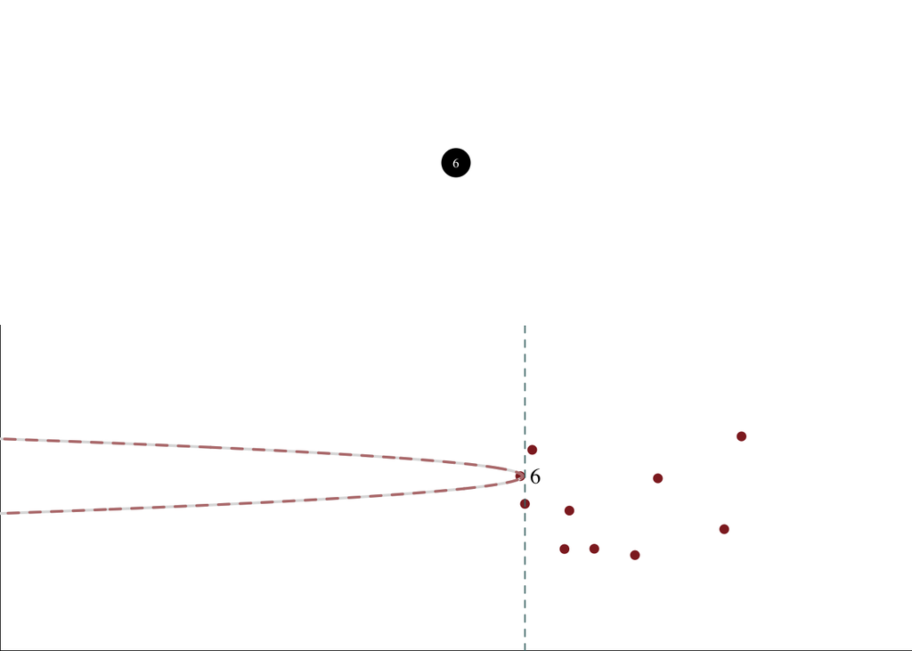

```
Remaining queue:
  S = -0.546 : Site Event at 2
  S = -0.090 : Site Event at 10
  S = -0.498 : Site Event at 1
  S = 0.177 : Site Event at 9
  S = 0.878 : Site Event at 5
  S = -0.286 : Site Event at 3
  S = -0.254 : Site Event at 7
  S = 0.328 : Site Event at 8
  S = 0.765 : Site Event at 4
```

```r
process_next_event()
```

The next site event splits this monolithic parabola up into three arcs and introduces the first Voronoi half-edges. Note that the lower arc is too small to be seen in this plot.

```
Processing Site Event (2)
```

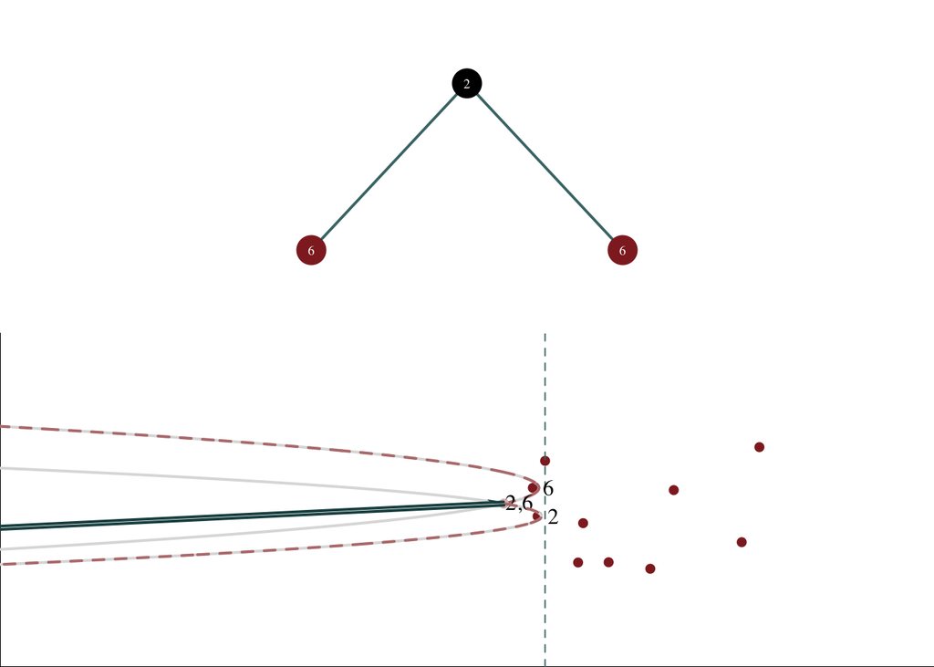

```
Remaining queue:
  S = -0.498 : Site Event at 1
  S = -0.090 : Site Event at 10
  S = -0.286 : Site Event at 3
  S = 0.177 : Site Event at 9
  S = 0.878 : Site Event at 5
  S = 0.765 : Site Event at 4
  S = -0.254 : Site Event at 7
  S = 0.328 : Site Event at 8
```

```r
process_next_event()
```

At this point we’ll jump through the next few events until we’re about to encounter our first vertex event.

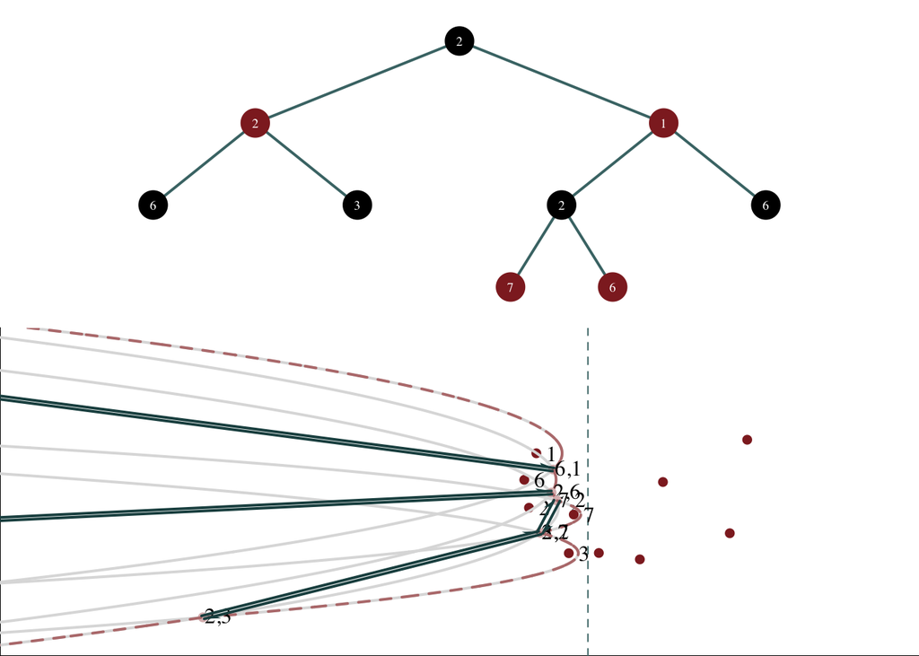

```r
for (i in 1:3) {
  bl$process_next_event(queue, voronoi)
}

par(mfrow=c(2, 1))

plot_tree(bl, text_cex=0.6)

plot_beachline(bl, queue$next_event()$x,
               c(-4, 2), c(-2, 2))
plot_beachline_half_edges(bl, S, col=c_dark_teal,
                          delta=0.08, eps=0.04, gamma=0.02)
```

```r
for (v in voronoi$vertices)
  plot_vertex_edges(v, ucol=c_light_teal,
                    delta=0.08, eps=0.04, gamma=0.02)

cat('')
cat('Remaining queue:')
```

```
Remaining queue:
```

```r
for (i in queue$idxs) {
  arc <- queue$events[[i]]$arc
  if (is.null(queue$events[[i]]$arc)) {
    cat(paste('  S =', sprintf('%.3f', queue$events[[i]]$x),
              ':',
              'Site Event at', queue$events[[i]]$site),
              '\n')
  } else {
    cat(paste('  S =', sprintf('%.3f', queue$events[[i]]$x),
              ':',
              'Vertex Event at', queue$events[[i]]$arc$site),
              '\n')
  }
}
```

```
  S = -0.162 : Vertex Event at 2
  S = -0.049 : Vertex Event at 2
  S = -0.090 : Site Event at 10
  S = 0.177 : Site Event at 9
  S = 0.878 : Site Event at 5
  S = 0.765 : Site Event at 4
  S = 0.328 : Site Event at 8
  S = 1.487 : Vertex Event at 6
```

In the first vertex event we start paring the beach line down. Here the arc node generated by site $2$ that sits between the breakpoints $b_{32}$ and $b_{27}$ is removed while our first Voronoi vertex is created.

```
Processing Vertex Event ( 2 )
```

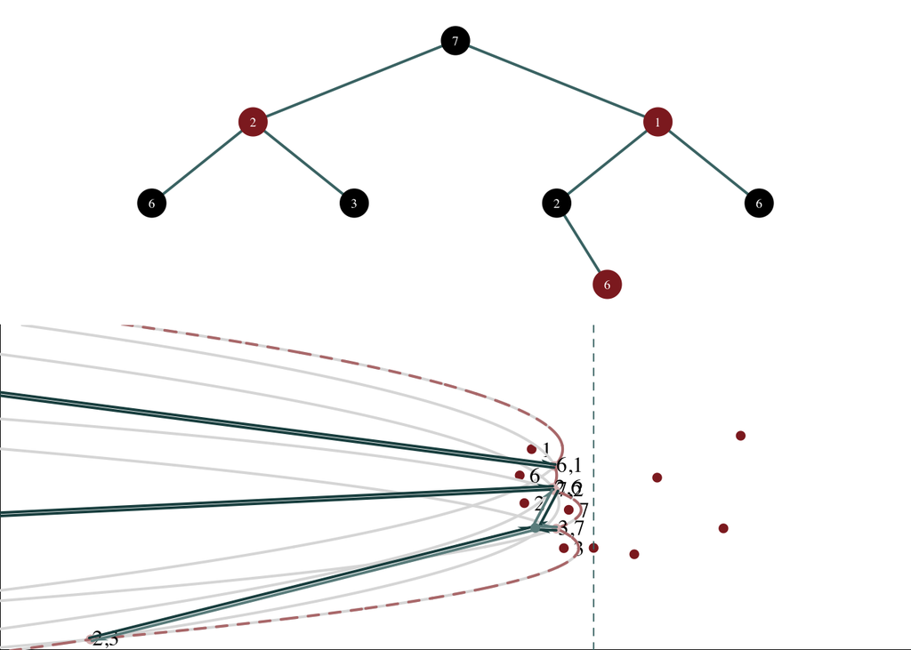

```
Remaining queue:
  S = -0.090 : Site Event at 10
  S = -0.049 : Vertex Event at 2
  S = 0.328 : Site Event at 8
  S = 0.177 : Site Event at 9
  S = 0.878 : Site Event at 5
  S = 0.765 : Site Event at 4
  S = 1.487 : Vertex Event at 6
```

```r
process_next_event()
```

To not draw this process out *too* long let’s run Fortune’s algorithm to completion.

```r
while (queue$is_not_empty()) {
  bl$process_next_event(queue, voronoi)
}
```

The remaining breakpoint nodes each contain a dangling Voronoi half-edge.

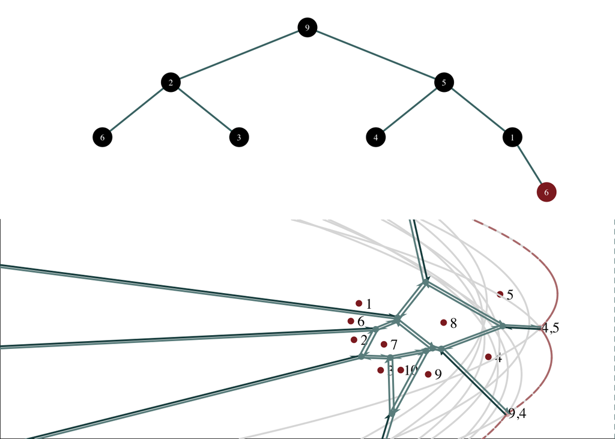

```r
par(mfrow=c(2, 1))
plot_tree(bl, text_cex=0.6)

plot_beachline(bl, 2,
               c(-4, 2), c(-2, 2))
plot_beachline_half_edges(bl, S, col=c_dark_teal,
                          delta=0.08, eps=0.04, gamma=0.02)
for (v in voronoi$vertices)
  plot_vertex_edges(v, ucol=c_light_teal,
                    delta=0.08, eps=0.04, gamma=0.02)
```

To visualize the entire Voronoi graph within the confines of a finite plot we’ll need a bounding box.

We can always specify a bounding box of our own. This can be useful, for example, if we want particular large or symmetric bounding boxes for visualization purposes.

```r
voronoi$xlim <- c(-3, 3)
voronoi$ylim <- c(-3, 3)
```

In most cases, however, it’s most convenient to dynamically adapt a bounding box to the Voronoi vertices.

```r
voronoi$compute_bounding_box(0.25)
```

Given a bounding box geometry we can anchor dangling half-edges to pseudo-vertices on the bounding box.

```r
voronoi$anchor_dangling_edges(bl$root, xs, ys)
```

Perhaps the simplest way to plot the Voronoi graph is to plot each Voronoi vertex along with the half-edges originating from and terminating at those vertices.

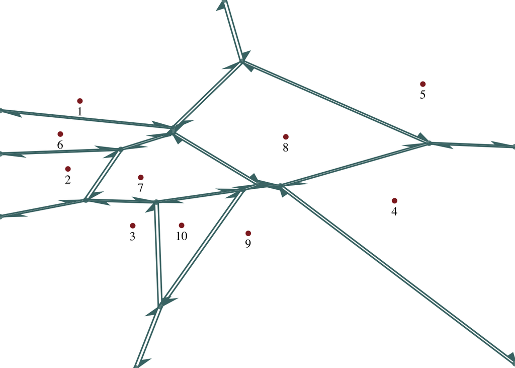

```r
par(mfrow=c(1, 1), mar=c(0, 0, 0, 0))
plot(xs, ys, axes=FALSE, ann=FALSE, col=c_dark, pch=16,
     xlim=voronoi$xlim, ylim=voronoi$ylim,
     main="")

for (n in 1:N)
  text(xs[n], ys[n] - 0.1, n)

for (v in voronoi$vertices)
  plot_vertex_edges(v, delta=0.08, eps=0.04, gamma=0.0075)

for (pv in voronoi$pseudo_vertices)
  plot_vertex_edges(pv, delta=0.08, eps=0.04, gamma=0.0075)
```

The real content of the Voronoi diagram, however, is in the faces.

```r
voronoi$find_faces()
```

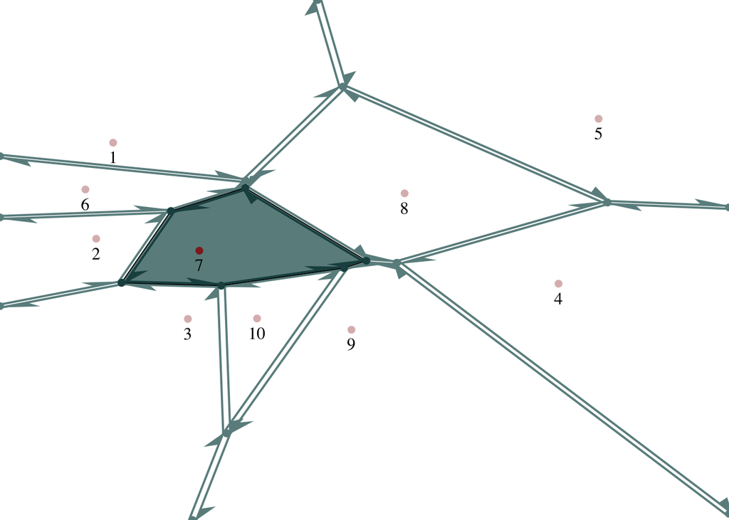

```r
par(mfrow=c(1, 1), mar=c(0, 0, 0, 0))
plot(xs, ys, axes=FALSE, ann=FALSE, col=c_light, pch=16,
     xlim=voronoi$xlim, ylim=voronoi$ylim,
     main="")

for (n in 1:N)
  text(xs[n], ys[n] - 0.1, n)

for (f in voronoi$faces) {
  plot_face_boundary(f, col=c_light_teal,
                     delta=0.08, eps=0.04, gamma=0.01)
}

f <- voronoi$faces[[1]]
plot_face(f, col=c_light_teal)
plot_face_boundary(f, col=c_dark_teal,
                   delta=0.08, eps=0.04, gamma=0.01)
points(xs[f$site], ys[f$site], col=c_dark, pch=16)
text(xs[f$site], ys[f$site] - 0.1, f$site)
```

The beautiful thing about Fortune’s algorithm is that scaling up to more sights is not particularly expensive.

```r
N <- 1000

xs <- runif(N, -1, 1)
ys <- runif(N, -1, 1)


queue <- event_queue$new(1:N, xs)

bl <- beachline$new()
voronoi <- dcel$new()


while (queue$is_not_empty()) {
  bl$process_next_event(queue, voronoi)
}
```

```r
voronoi$compute_bounding_box(0.25)

voronoi$anchor_dangling_edges(bl$root, xs, ys)
```

```r
voronoi$find_faces()
```

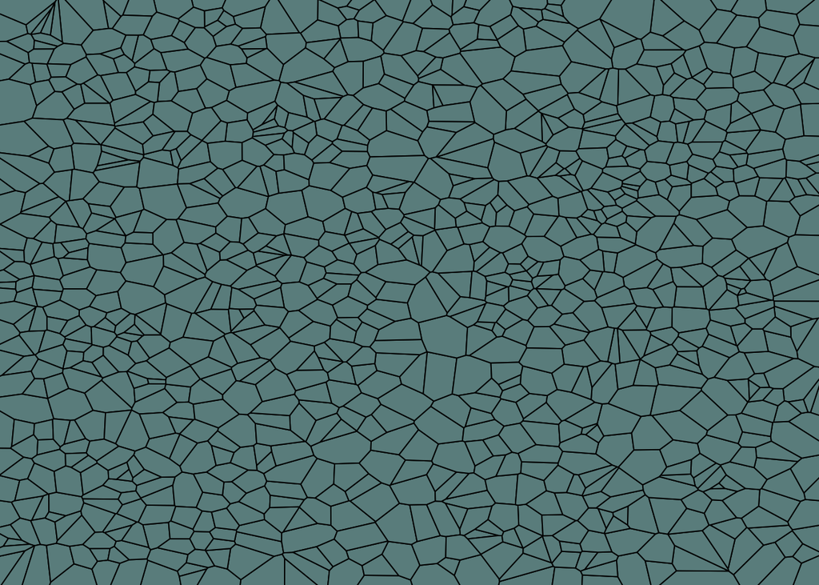

```r
par(mfrow=c(1, 1), mar=c(0, 0, 0, 0))

plot(xs, ys, col=c_light, pch=16,
     xlim=c(-1, 1), ylim=c(-1, 1),
     main="")

for (f in voronoi$faces) {
  plot_face(f, col=c_light_teal)
}
```

# 6 Conclusion

Voronoi diagrams are straightforward to define but subtle to construct in practice, especially if we want to maximize computational efficiency. Fortune’s algorithm systematizes the construction of Voronoi diagrams, but understanding how the algorithm actually works requires immersing ourselves in planar geometry. Moreover, effectively implementing Fortune’s algorithm in practice requires familiarity with a variety of nontrivial data structures.

From a more optimistic perspective, Fortune’s algorithm provides a wealth of learning opportunities…

# Acknowledgements

A very special thanks to everyone supporting me on Patreon: Adam Fleischhacker, Alejandro Morales, Alessandro Varacca, Alex D, Alexander Noll, Amit, Andrea Serafino, Andrew Mascioli, Andrew Rouillard, Ara Winter, Ari Holtzman, Austin Rochford, Aviv Keshet, Avraham Adler, Ben Matthews, Ben Swallow, Benoit Essiambre, boot, Brendan Galdo, Bryan Chang, Brynjolfur Gauti Jónsson, Cameron Smith, Canaan Breiss, Cat Shark, Cathy Oliveri, Charles Naylor, Chase Dwelle, Chris Jones, Christina Van Heer, Christopher Mehrvarzi, Colin Carroll, Colin McAuliffe, Damien Mannion, dan mackinlay, Dan W Joyce, Dan Waxman, Dan Weitzenfeld, Daniel Edward Marthaler, Danny Van Nest, David Burdelski, Doug Rivers, Dr. Jobo, Dr. Omri Har Shemesh, Dylan Maher, Dylan Spielman, Ed Cashin, Edgar Merkle, Edoardo Marcora, Eric LaMotte, Erik Banek, Eugene O’Friel, Felipe González, Fergus Chadwick, Finn Lindgren, Francesco Corona, Geoff Rollins, Granville Matheson, Gregor Gorjanc, Guilherme Marthe, Håkan Johansson, Hamed Bastan-Hagh, haubur, Hector Munoz, Henri Wallen, hs, Hugo Botha, Ian Costley, idontgetoutmuch, Ignacio Vera, Ilaria Prosdocimi, Isaac Vock, Isidor Belic, jacob pine, Jair Andrade, James C, James Hodgson, James Wade, Janek Berger, Jarrett Byrnes, Jason Martin, Jason Pekos, Jason Wong, jd, Jed , Jeff Burnett, Jeff Dotson, Jeff Helzner, Jeffrey Erlich, Jerry Lin , Jessica Graves, Joe Sloan, John Flournoy, Jonathan H. Morgan, Josh Knecht, JU, Julian Lee, June, Justin Bois, Kádár András, Karim Naguib, Karim Osman, Konstantin Shakhbazov, Kristian Gårdhus Wichmann, Lars Barquist, lizzie , LOU ODETTE, Luís F, Mads Christian Hansen, Marek Kwiatkowski, Mariana Carmona, Mark Donoghoe, Markus P., Márton Vaitkus, Matěj, Matthew, Matthew Kay, Matthieu LEROY, Mattia Arsendi, Maurits van der Meer, Max, Michael Colaresi, Michael DeWitt, Michael Dillon, Michael Lerner, Mick Cooney, MisterMentat , N Sanders, N.S. , Name, Nathaniel Burbank, Nicholas Cowie, Nick S, Nikita Karetnikov, Octavio Medina, Ole Rogeberg, Oliver Crook, Olivier Ma, Patrick Kelley, Patrick Boehnke, Pau Pereira Batlle, Peter Johnson, Pieter van den Berg , ptr, quasar, Ramiro Barrantes Reynolds, Raúl Peralta Lozada, Ravin Kumar, Rex, Riccardo Fusaroli, Richard Nerland, Robert Frost, Robert Goldman, Robert kohn, Robin Taylor, Ryan Gan, Ryan Grossman, S Hong, Sean Wilson, Sergiy Protsiv, Seth Axen, shira, Simon Duane, Simon Lilburn, Simon Steiger, Simone, Spencer Boucher, sssz, Stefan Lorenz, Stephen Lienhard, Steve Harris, Steven Forrest, Stew Watts, Stone Chen, Susan Holmes, Svilup, Tate Tunstall, Tatsuo Okubo, Teresa Ortiz, Theodore Dasher, Thomas Siegert, Thomas Vladeck, Tobychev , Tomas Capretto, Tony Wuersch, Virgile Andreani, Virginia Fisher, Vitalie Spinu, Vladimir Markov, VO2 Maximus Decius, Will Farr, Will Lowe, Will Wen, woejozney, yolhaj , yureq , Zach A, and Zhengchen Cai.

# References

Berg, Mark de, Otfried Cheong, Marc van Kreveld, and Mark Overmars. 2008. *Computational Geometry*. Third. Springer-Verlag, Berlin.

Chang, Winston. 2025. *R6: Encapsulated Classes with Reference Semantics*.

Cormen, Thomas H, Charles E Leiserson, Ronald L Rivest, and Clifford Stein. 2022. *Introduction to Algorithms*. Fourth. Cambridge, MA: MIT Press.

Fortune, Steven. 1987. “A Sweepline Algorithm for Voronoı̆ Diagrams.” *Algorithmica* 2 (2): 153–74.

# License

A repository containing all of the files used to generate this chapter is available on [GitHub](https://github.com/betanalpha/quarto_misc/tree/main/voronoi).

The code in this case study is copyrighted by Michael Betancourt and licensed under the new BSD (3-clause) license:

https://opensource.org/licenses/BSD-3-Clause

The text and figures in this chapter are copyrighted by Michael Betancourt and licensed under the CC BY-NC 4.0 license:

https://creativecommons.org/licenses/by-nc/4.0/